# Stock Counts 52 Machine Learning

Janis Corona

3/17/2020

```r
library(e1071)
library(caret)
library(randomForest)
library(MASS)
library(gbm)

library(dplyr)
library(tidyr)
library(lubridate)
```

These are the lag1 entries to compare to the next day or today stock values where today is the instance date.

```r
stocks_65 <- read.csv('ALL_65_stocks_countGroups_1999-01-01_2020-03-15_lag1.csv', sep=',', header=TRUE,
                     na.strings=c('',' ','NA'))
```

```r
head(stocks_65)
```

```
##   stockName
## 1       AAL
## 2       AAL
## 3       AAL
## 4       AAL
## 5       AAL
## 6       AAL
##                                                                                  stockInfo
## 1 American Airlines Group Inc. (AAL)\nNasdaqGS - NasdaqGS Real Time Price. Currency in USD
## 2 American Airlines Group Inc. (AAL)\nNasdaqGS - NasdaqGS Real Time Price. Currency in USD
## 3 American Airlines Group Inc. (AAL)\nNasdaqGS - NasdaqGS Real Time Price. Currency in USD
## 4 American Airlines Group Inc. (AAL)\nNasdaqGS - NasdaqGS Real Time Price. Currency in USD
## 5 American Airlines Group Inc. (AAL)\nNasdaqGS - NasdaqGS Real Time Price. Currency in USD
## 6 American Airlines Group Inc. (AAL)\nNasdaqGS - NasdaqGS Real Time Price. Currency in USD
##   stockExchange       Date DayOfWeek Month Year MonthYear stockDayValue
```

[output cut: 41 more lines]

```r
colnames(stocks_65)
```

```
##  [1] "stockName"                      "stockInfo"
##  [3] "stockExchange"                  "Date"
##  [5] "DayOfWeek"                      "Month"
##  [7] "Year"                           "MonthYear"
##  [9] "stockDayValue"                  "startDayValue"
## [11] "startDayDate"                   "finalDayValue"
## [13] "finalDayDate"                   "lag1"
## [15] "today2lag1"                     "todayGrtrThanlag1"
## [17] "cumulativeSumTodayGrtrThanlag1" "nRepeatsTodayGrtrThanlag1"
## [19] "decrDaysThisCycle"              "nTimesDecrDayCountsOccurs"
## [21] "todayLessThanlag1"              "cumulativeSumTodayLessThanlag1"
## [23] "nRepeatsTodayLessThanlag1"      "incrDaysThisCycle"
## [25] "nTimesIncrDayCountsOccurs"
```

Create a subset of the 65 stocks data of the AAL stock.

```r
sAAL <- subset(stocks_65, stocks_65$stockName =='AAL')
row.names(sAAL) <- sAAL$Date
sAAL <- sAAL[,c(5,9,14:25)]
head(sAAL)
```

```
##            DayOfWeek stockDayValue  lag1 today2lag1 todayGrtrThanlag1
## 2005-09-28 Wednesday         20.50 19.30  1.0621762                 1
## 2005-09-29  Thursday         20.21 20.50  0.9858536                 0
## 2005-09-30    Friday         21.01 20.21  1.0395844                 1
## 2005-10-03    Monday         21.50 21.01  1.0233222                 1
## 2005-10-04   Tuesday         22.16 21.50  1.0306977                 1
## 2005-10-05 Wednesday         22.20 22.16  1.0018051                 1
##            cumulativeSumTodayGrtrThanlag1 nRepeatsTodayGrtrThanlag1
## 2005-09-28                              1                         2
## 2005-09-29                              1                         2
## 2005-09-30                              2                         1
## 2005-10-03                              3                         1
## 2005-10-04                              4                         1
## 2005-10-05                              5                         1
##            decrDaysThisCycle nTimesDecrDayCountsOccurs todayLessThanlag1
## 2005-09-28                 1                       411                 0
## 2005-09-29                 1                       411                 1
## 2005-09-30                 0                       943                 0
## 2005-10-03                 0                       943                 0
## 2005-10-04                 0                       943                 0
## 2005-10-05                 0                       943                 0
##            cumulativeSumTodayLessThanlag1 nRepeatsTodayLessThanlag1
## 2005-09-28                              0                         1
## 2005-09-29                              1                         6
## 2005-09-30                              1                         6
## 2005-10-03                              1                         6
## 2005-10-04                              1                         6
## 2005-10-05                              1                         6
##            incrDaysThisCycle nTimesIncrDayCountsOccurs
## 2005-09-28                 0                       955
## 2005-09-29                 5                        30
## 2005-09-30                 5                        30
## 2005-10-03                 5                        30
## 2005-10-04                 5                        30
## 2005-10-05                 5                        30
```

```r
str(sAAL)
```

```
## 'data.frame':    3639 obs. of  14 variables:
##  $ DayOfWeek                     : Factor w/ 5 levels "Friday","Monday",..: 5 3 1 2 4 5 3 1 2 4 ...
##  $ stockDayValue                 : num  20.5 20.2 21 21.5 22.2 ...
##  $ lag1                          : num  19.3 20.5 20.2 21 21.5 ...
##  $ today2lag1                    : num  1.062 0.986 1.04 1.023 1.031 ...
##  $ todayGrtrThanlag1             : int  1 0 1 1 1 1 1 0 1 0 ...
##  $ cumulativeSumTodayGrtrThanlag1: int  1 1 2 3 4 5 6 6 7 7 ...
##  $ nRepeatsTodayGrtrThanlag1     : int  2 2 1 1 1 1 2 2 4 4 ...
##  $ decrDaysThisCycle             : int  1 1 0 0 0 0 1 1 3 3 ...
##  $ nTimesDecrDayCountsOccurs     : int  411 411 943 943 943 943 411 411 107 107 ...
##  $ todayLessThanlag1             : int  0 1 0 0 0 0 0 1 0 1 ...
##  $ cumulativeSumTodayLessThanlag1: int  0 1 1 1 1 1 1 2 2 3 ...
##  $ nRepeatsTodayLessThanlag1     : int  1 6 6 6 6 6 6 2 2 1 ...
##  $ incrDaysThisCycle             : int  0 5 5 5 5 5 5 1 1 0 ...
##  $ nTimesIncrDayCountsOccurs     : int  955 30 30 30 30 30 30 408 408 955 ...
```

Try predicting the number of increasing days this cycle for the AAL stock as a subset.

```r
set.seed(12356789)

inTrain <- createDataPartition(y=sAAL$incrDaysThisCycle, p=0.7, list=FALSE)

trainingSet <- sAAL[inTrain,]
testingSet <- sAAL[-inTrain,]
```

```r
rfMod <- train(incrDaysThisCycle ~ ., method='rf', data=(trainingSet),
               trControl=trainControl(method='cv'), number=5)
```

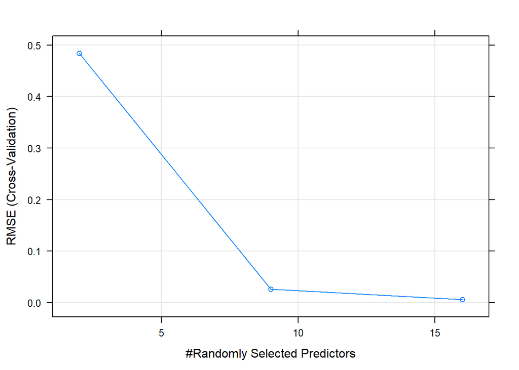

```r
plot(rfMod)
```

```r
predRF <- predict(rfMod, testingSet)

predDF <- data.frame(predRF, type=testingSet$incrDaysThisCycle)
predDF
```

```
##                   predRF type
## 2005-09-28  8.540000e-01    0
## 2005-10-07  1.046000e+00    1
## 2005-10-10  1.050000e+00    1
## 2005-10-14  1.052000e+00    1
## 2005-10-19  3.600000e-02    0
## 2005-10-21  1.988000e+00    2
## 2005-10-24  1.996000e+00    2
## 2005-10-28  1.500000e+01   15
## 2005-11-14  1.499000e+01   15
## 2005-11-16  1.038000e+00    1
## 2005-11-22  1.998000e+00    2
## 2005-11-23  2.012000e+00    2
## 2005-12-06  1.998000e+00    2
## 2005-12-12  3.000000e-02    0
## 2005-12-13  7.972000e+00    8
## 2005-12-14  7.970000e+00    8
## 2005-12-16  7.984000e+00    8
## 2005-12-23  7.992000e+00    8
## 2005-12-27  1.200000e-02    0
## 2005-12-29  4.200000e-02    0
## 2006-01-05  2.976000e+00    3
## 2006-01-06 -7.818635e-15    0
## 2006-01-09  8.000000e-03    0
## 2006-01-19  2.600000e-02    0
## 2006-01-23  1.996000e+00    2
## 2006-01-24  2.000000e+00    2
## 2006-01-26  2.600000e-02    0
## 2006-01-27  3.992000e+00    4
## 2006-02-01  3.978000e+00    4
## 2006-02-03  1.000000e-02    0
## 2006-02-07  2.000000e+00    2
## 2006-02-10  2.986000e+00    3
## 2006-02-15  2.996000e+00    3
## 2006-03-03  6.000000e-03    0
## 2006-03-09  1.000000e+00    1
## 2006-03-20  7.000000e+00    7
## 2006-03-24  9.980000e-01    1
## 2006-03-28  1.004000e+00    1
## 2006-03-29  1.004000e+00    1
```

[output cut: 1036 more lines]

```
## 2020-01-22  1.998000e+00    2
## 2020-01-23  2.000000e+00    2
## 2020-01-27  1.000000e+00    1
## 2020-02-07  4.000000e+00    4
## 2020-02-13  2.000000e-03    0
## 2020-02-14  2.000000e-03    0
## 2020-02-18 -6.883383e-15    0
## 2020-02-21 -7.769785e-15    0
## 2020-02-24 -6.793677e-15    0
## 2020-02-25 -6.684431e-15    0
## 2020-02-27 -6.854073e-15    0
## 2020-03-06 -7.920775e-15    0
## 2020-03-09  1.002000e+00    1
## 2020-03-11 -6.752821e-15    0
## 2020-03-12  1.002000e+00    1
```

```r
sum <- sum(predRF==testingSet$incrDaysThisCycle)
length <- length(testingSet$incrDaysThisCycle)
accuracy_rfMod <- (sum/length)
accuracy_rfMod
```

```
## [1] 0.4981651
```

```r
results <- c(round(accuracy_rfMod,2), round(100,2))
results <- as.factor(results)
results <- t(data.frame(results))

colnames(results) <- colnames(predDF)
Results <- rbind(predDF, results)
Results
```

```
##                           predRF type
## 2005-09-28     0.853999999999997    0
## 2005-10-07                 1.046    1
## 2005-10-10                  1.05    1
## 2005-10-14                 1.052    1
## 2005-10-19     0.035999999999994    0
## 2005-10-21                 1.988    2
## 2005-10-24                 1.996    2
## 2005-10-28                    15   15
## 2005-11-14                 14.99   15
## 2005-11-16                 1.038    1
## 2005-11-22                 1.998    2
## 2005-11-23                 2.012    2
## 2005-12-06                 1.998    2
## 2005-12-12    0.0299999999999932    0
## 2005-12-13                 7.972    8
## 2005-12-14                  7.97    8
## 2005-12-16                 7.984    8
## 2005-12-23                 7.992    8
## 2005-12-27    0.0119999999999932    0
## 2005-12-29    0.0419999999999933    0
## 2006-01-05                 2.976    3
## 2006-01-06  -7.8186346286202e-15    0
## 2006-01-09   0.00799999999999316    0
## 2006-01-19    0.0259999999999931    0
## 2006-01-23                 1.996    2
## 2006-01-24                     2    2
## 2006-01-26     0.025999999999993    0
## 2006-01-27                 3.992    4
## 2006-02-01                 3.978    4
## 2006-02-03   0.00999999999999204    0
## 2006-02-07                     2    2
## 2006-02-10                 2.986    3
## 2006-02-15                 2.996    3
## 2006-03-03   0.00599999999999211    0
## 2006-03-09                     1    1
## 2006-03-20                     7    7
## 2006-03-24                 0.998    1
## 2006-03-28                 1.004    1
## 2006-03-29                 1.004    1
```

[output cut: 1037 more lines]

```
## 2020-01-23                     2    2
## 2020-01-27                     1    1
## 2020-02-07                     4    4
## 2020-02-13   0.00199999999999293    0
## 2020-02-14   0.00199999999999205    0
## 2020-02-18 -6.88338275267597e-15    0
## 2020-02-21 -7.76978481553669e-15    0
## 2020-02-24 -6.79367673228626e-15    0
## 2020-02-25 -6.68443078666314e-15    0
## 2020-02-27 -6.85407286482587e-15    0
## 2020-03-06 -7.92077514688572e-15    0
## 2020-03-09                 1.002    1
## 2020-03-11 -6.75282052498005e-15    0
## 2020-03-12                 1.002    1
## results                      0.5  100
```

```r
knnMod <- train(incrDaysThisCycle ~ .,
                method='knn', preProcess=c('center','scale'),
                tuneLength=10, trControl=trainControl(method='cv'), data=trainingSet)
```

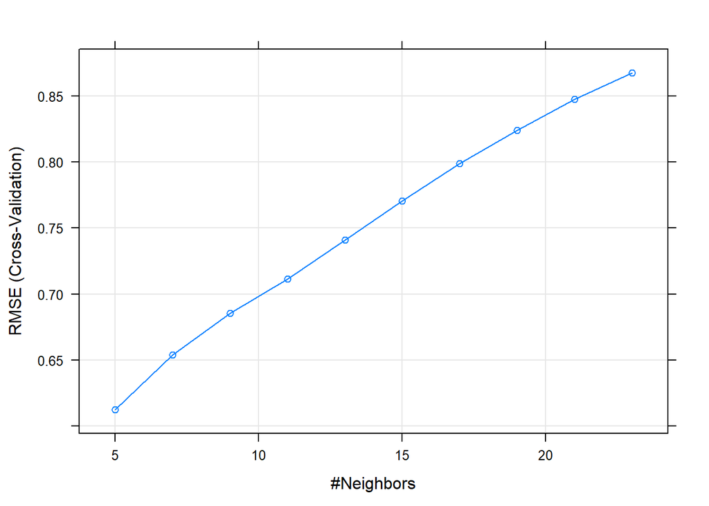

```r
plot(knnMod)
```

```r
rpartMod <- train(incrDaysThisCycle ~ ., method='rpart', tuneLength=9, data=trainingSet)
```

```r
glmMod <- train(incrDaysThisCycle ~ .,
                method='glm', data=trainingSet)
```

```r
predKNN <- predict(knnMod, testingSet)
predRPART <- predict(rpartMod, testingSet)
```

```r
predGLM <- predict(glmMod, testingSet)
```

```r
length=length(testingSet$incrDaysThisCycle)
```

```r
sumKNN <- sum(predKNN==testingSet$incrDaysThisCycle)
sumRPart <- sum(predRPART==testingSet$incrDaysThisCycle)
```

```r
sumGLM <- sum(predGLM==testingSet$incrDaysThisCycle)
```

```r
accuracy_KNN <- sumKNN/length
accuracy_RPART <- sumRPart/length
```

```r
accuracy_GLM <- sumGLM/length
```

```r
predDF2 <- data.frame(predRF,predKNN,predRPART,predGLM,
                      TYPE=testingSet$incrDaysThisCycle)
colnames(predDF2) <- c('RandomForest','KNN','Rpart','GLM','TrueValue')

results <- c(round(accuracy_rfMod,2),
             round(accuracy_KNN,2),
             round(accuracy_RPART,2),
             round(accuracy_GLM,2),
             round(100,2))

results <- as.factor(results)
results <- t(data.frame(results))
colnames(results) <- c('RandomForest','KNN','Rpart','GLM','TrueValue')
Results <- rbind(predDF2, results)
Results
```

```
##                     RandomForest  KNN            Rpart                   GLM
## 2005-09-28     0.853999999999997    1                0 -2.42070207540644e-14
## 2005-10-07                 1.046  1.8                1     0.999999999999965
## 2005-10-10                  1.05  1.4                1                     1
## 2005-10-14                 1.052    1                1     0.999999999999974
## 2005-10-19     0.035999999999994    0                0 -3.10904035067404e-14
## 2005-10-21                 1.988  3.2                2      1.99999999999997
## 2005-10-24                 1.996  1.8                2                     2
## 2005-10-28                    15   15             14.4      14.9999999999999
## 2005-11-14                 14.99 13.6             14.4                    15
## 2005-11-16                 1.038  1.4                1     0.999999999999965
## 2005-11-22                 1.998  2.2                2      1.99999999999998
## 2005-11-23                 2.012    2                2      1.99999999999997
## 2005-12-06                 1.998  2.2                2      1.99999999999998
## 2005-12-12    0.0299999999999932    0                0 -5.77731854528682e-15
## 2005-12-13                 7.972  3.6 8.65116279069767      7.99999999999995
## 2005-12-14                  7.97  5.8 8.65116279069767      7.99999999999996
## 2005-12-16                 7.984  5.6 8.65116279069767      7.99999999999996
## 2005-12-23                 7.992  4.2 8.65116279069767      7.99999999999995
## 2005-12-27    0.0119999999999932    0                0 -2.70936006180898e-14
## 2005-12-29    0.0419999999999933    0                0 -2.79817790377899e-14
## 2006-01-05                 2.976  2.4                3      2.99999999999997
## 2006-01-06  -7.8186346286202e-15    0                0 -3.15344927165904e-14
## 2006-01-09   0.00799999999999316    0                0 -4.66709552066166e-15
## 2006-01-19    0.0259999999999931    0                0 -2.59833775934647e-14
## 2006-01-23                 1.996    3                2                     2
## 2006-01-24                     2  1.4                2      1.99999999999997
## 2006-01-26     0.025999999999993    0                0 -2.53172437786896e-14
## 2006-01-27                 3.992    3                4      3.99999999999996
## 2006-02-01                 3.978  3.2                4      3.99999999999997
## 2006-02-03   0.00999999999999204    0                0 -3.19785819264405e-14
## 2006-02-07                     2    2                2      1.99999999999997
## 2006-02-10                 2.986  2.4                3      2.99999999999996
## 2006-02-15                 2.996  2.4                3      2.99999999999997
## 2006-03-03   0.00599999999999211    0                0 -3.04242696919653e-14
## 2006-03-09                     1  1.6                1     0.999999999999971
## 2006-03-20                     7  6.4 6.24242424242424      6.99999999999999
## 2006-03-24                 0.998  1.2                1     0.999999999999963
## 2006-03-28                 1.004    2                1     0.999999999999974
## 2006-03-29                 1.004  1.8                1     0.999999999999976
```

[output cut: 2129 more lines]

```
## 2020-01-23         2
## 2020-01-27         1
## 2020-02-07         4
## 2020-02-13         0
## 2020-02-14         0
## 2020-02-18         0
## 2020-02-21         0
## 2020-02-24         0
## 2020-02-25         0
## 2020-02-27         0
## 2020-03-06         0
## 2020-03-09         1
## 2020-03-11         0
## 2020-03-12         1
## results          100
```

When looking at the above table, the errors are based on an exact match, but the values you notice as I do, are rounded up to the true value if greater than zero and zero if less than zero will give very near perfect results for predicting the number of days the cycle will be increasing. Lets test this out.

```r
predRF_round <- predict(rfMod, testingSet)

predRF_round <- ifelse(predRF_round<0,0,round(predRF,0))

predDF_round <- data.frame(predRF_round, IncreasingDaysThisCycle=testingSet$incrDaysThisCycle)
predDF_round
```

```
##            predRF_round IncreasingDaysThisCycle
## 2005-09-28            1                       0
## 2005-10-07            1                       1
## 2005-10-10            1                       1
## 2005-10-14            1                       1
## 2005-10-19            0                       0
## 2005-10-21            2                       2
## 2005-10-24            2                       2
## 2005-10-28           15                      15
## 2005-11-14           15                      15
## 2005-11-16            1                       1
## 2005-11-22            2                       2
## 2005-11-23            2                       2
## 2005-12-06            2                       2
## 2005-12-12            0                       0
## 2005-12-13            8                       8
## 2005-12-14            8                       8
## 2005-12-16            8                       8
## 2005-12-23            8                       8
## 2005-12-27            0                       0
## 2005-12-29            0                       0
## 2006-01-05            3                       3
## 2006-01-06            0                       0
## 2006-01-09            0                       0
## 2006-01-19            0                       0
## 2006-01-23            2                       2
## 2006-01-24            2                       2
## 2006-01-26            0                       0
## 2006-01-27            4                       4
## 2006-02-01            4                       4
## 2006-02-03            0                       0
## 2006-02-07            2                       2
## 2006-02-10            3                       3
## 2006-02-15            3                       3
## 2006-03-03            0                       0
## 2006-03-09            1                       1
## 2006-03-20            7                       7
## 2006-03-24            1                       1
## 2006-03-28            1                       1
## 2006-03-29            1                       1
```

[output cut: 1036 more lines]

```
## 2020-01-22            2                       2
## 2020-01-23            2                       2
## 2020-01-27            1                       1
## 2020-02-07            4                       4
## 2020-02-13            0                       0
## 2020-02-14            0                       0
## 2020-02-18            0                       0
## 2020-02-21            0                       0
## 2020-02-24            0                       0
## 2020-02-25            0                       0
## 2020-02-27            0                       0
## 2020-03-06            0                       0
## 2020-03-09            1                       1
## 2020-03-11            0                       0
## 2020-03-12            1                       1
```

```r
sum <- sum(predRF_round==testingSet$incrDaysThisCycle)
length <- length(testingSet$incrDaysThisCycle)
accuracy_rfMod_round <- (sum/length)
accuracy_rfMod_round
```

```
## [1] 0.9990826
```

```r
results_round <- c(round(accuracy_rfMod_round,2), round(100,2))
results_round <- as.factor(results_round)
results_round <- t(data.frame(results_round))

colnames(results_round) <- colnames(predDF_round)
Results_round <- rbind(predDF_round, results_round)
Results_round
```

```
##               predRF_round IncreasingDaysThisCycle
## 2005-09-28               1                       0
## 2005-10-07               1                       1
## 2005-10-10               1                       1
## 2005-10-14               1                       1
## 2005-10-19               0                       0
## 2005-10-21               2                       2
## 2005-10-24               2                       2
## 2005-10-28              15                      15
## 2005-11-14              15                      15
## 2005-11-16               1                       1
## 2005-11-22               2                       2
## 2005-11-23               2                       2
## 2005-12-06               2                       2
## 2005-12-12               0                       0
## 2005-12-13               8                       8
## 2005-12-14               8                       8
## 2005-12-16               8                       8
## 2005-12-23               8                       8
## 2005-12-27               0                       0
## 2005-12-29               0                       0
## 2006-01-05               3                       3
## 2006-01-06               0                       0
## 2006-01-09               0                       0
## 2006-01-19               0                       0
## 2006-01-23               2                       2
## 2006-01-24               2                       2
## 2006-01-26               0                       0
## 2006-01-27               4                       4
## 2006-02-01               4                       4
## 2006-02-03               0                       0
## 2006-02-07               2                       2
## 2006-02-10               3                       3
## 2006-02-15               3                       3
## 2006-03-03               0                       0
## 2006-03-09               1                       1
## 2006-03-20               7                       7
## 2006-03-24               1                       1
## 2006-03-28               1                       1
## 2006-03-29               1                       1
```

[output cut: 1037 more lines]

```
## 2020-01-23               2                       2
## 2020-01-27               1                       1
## 2020-02-07               4                       4
## 2020-02-13               0                       0
## 2020-02-14               0                       0
## 2020-02-18               0                       0
## 2020-02-21               0                       0
## 2020-02-24               0                       0
## 2020-02-25               0                       0
## 2020-02-27               0                       0
## 2020-03-06               0                       0
## 2020-03-09               1                       1
## 2020-03-11               0                       0
## 2020-03-12               1                       1
## results_round            1                     100
```

```r
knnMod_round <- train(incrDaysThisCycle ~ .,
                method='knn', preProcess=c('center','scale'),
                tuneLength=10, trControl=trainControl(method='cv'), data=trainingSet)
```

```r
rpartMod_round <- train(incrDaysThisCycle ~ ., method='rpart', tuneLength=9, data=trainingSet)
```

```r
glmMod_round <- train(incrDaysThisCycle ~ .,
                method='glm', data=trainingSet)
```

```r
predKNN <- predict(knnMod_round, testingSet)
predKNN_round <- ifelse(predKNN<0,0,round(predKNN,0))

predRPART <- predict(rpartMod_round, testingSet)
predRPART_round <- ifelse(predRPART<0,0,round(predRPART,0))
```

```r
predGLM <- predict(glmMod_round, testingSet)
predGLM_round <- ifelse(predGLM<0,0,round(predGLM,0))
```

```r
length=length(testingSet$incrDaysThisCycle)
```

```r
sumKNN_round <- sum(predKNN_round==testingSet$incrDaysThisCycle)
sumRPart_round <- sum(predRPART_round==testingSet$incrDaysThisCycle)
```

```r
sumGLM_round <- sum(predGLM_round==testingSet$incrDaysThisCycle)
```

```r
accuracy_KNN_round <- sumKNN_round/length
accuracy_RPART_round <- sumRPart_round/length
```

```r
accuracy_GLM_round <- sumGLM_round/length
```

```r
predDF2_round <- data.frame(predRF_round,predKNN_round,predRPART_round,predGLM_round,
                      IncreasingDaysThisCycle=testingSet$incrDaysThisCycle)
colnames(predDF2_round) <- c('RandomForest_round','KNN_round','Rpart_round','GLM_round','IncreasingDaysThisCycle')

results_round <- c(round(accuracy_rfMod_round,2),
             round(accuracy_KNN_round,2),
             round(accuracy_RPART_round,2),
             round(accuracy_GLM_round,2),
             round(100,2))

results_round <- as.factor(results_round)
results_round <- t(data.frame(results_round))
colnames(results_round) <- c('RandomForest_round','KNN_round','Rpart_round','GLM_round','IncreasingDaysThisCycle')
Results_round <- rbind(predDF2_round, results_round)
Results_round
```

```
##               RandomForest_round KNN_round Rpart_round GLM_round
## 2005-09-28                     1         1           0         0
## 2005-10-07                     1         2           1         1
## 2005-10-10                     1         1           1         1
## 2005-10-14                     1         1           1         1
## 2005-10-19                     0         0           0         0
## 2005-10-21                     2         3           2         2
## 2005-10-24                     2         2           2         2
## 2005-10-28                    15        15          14        15
## 2005-11-14                    15        14          14        15
## 2005-11-16                     1         1           1         1
## 2005-11-22                     2         2           2         2
## 2005-11-23                     2         2           2         2
## 2005-12-06                     2         2           2         2
## 2005-12-12                     0         0           0         0
## 2005-12-13                     8         4           9         8
## 2005-12-14                     8         6           9         8
## 2005-12-16                     8         6           9         8
## 2005-12-23                     8         4           9         8
## 2005-12-27                     0         0           0         0
## 2005-12-29                     0         0           0         0
## 2006-01-05                     3         2           3         3
## 2006-01-06                     0         0           0         0
## 2006-01-09                     0         0           0         0
## 2006-01-19                     0         0           0         0
## 2006-01-23                     2         3           2         2
## 2006-01-24                     2         1           2         2
## 2006-01-26                     0         0           0         0
## 2006-01-27                     4         3           4         4
## 2006-02-01                     4         3           4         4
## 2006-02-03                     0         0           0         0
## 2006-02-07                     2         2           2         2
## 2006-02-10                     3         2           3         3
## 2006-02-15                     3         2           3         3
## 2006-03-03                     0         0           0         0
## 2006-03-09                     1         2           1         1
## 2006-03-20                     7         6           6         7
## 2006-03-24                     1         1           1         1
## 2006-03-28                     1         2           1         1
## 2006-03-29                     1         2           1         1
```

[output cut: 2129 more lines]

```
## 2020-01-23                          2
## 2020-01-27                          1
## 2020-02-07                          4
## 2020-02-13                          0
## 2020-02-14                          0
## 2020-02-18                          0
## 2020-02-21                          0
## 2020-02-24                          0
## 2020-02-25                          0
## 2020-02-27                          0
## 2020-03-06                          0
## 2020-03-09                          1
## 2020-03-11                          0
## 2020-03-12                          1
## results_round                     100
```

Lets compare this to the table we just saw earlier when the values weren’t rounded or zero if less than zero.

```r
Results
```

```
##                     RandomForest  KNN            Rpart                   GLM
## 2005-09-28     0.853999999999997    1                0 -2.42070207540644e-14
## 2005-10-07                 1.046  1.8                1     0.999999999999965
## 2005-10-10                  1.05  1.4                1                     1
## 2005-10-14                 1.052    1                1     0.999999999999974
## 2005-10-19     0.035999999999994    0                0 -3.10904035067404e-14
## 2005-10-21                 1.988  3.2                2      1.99999999999997
## 2005-10-24                 1.996  1.8                2                     2
## 2005-10-28                    15   15             14.4      14.9999999999999
## 2005-11-14                 14.99 13.6             14.4                    15
## 2005-11-16                 1.038  1.4                1     0.999999999999965
## 2005-11-22                 1.998  2.2                2      1.99999999999998
## 2005-11-23                 2.012    2                2      1.99999999999997
## 2005-12-06                 1.998  2.2                2      1.99999999999998
## 2005-12-12    0.0299999999999932    0                0 -5.77731854528682e-15
## 2005-12-13                 7.972  3.6 8.65116279069767      7.99999999999995
## 2005-12-14                  7.97  5.8 8.65116279069767      7.99999999999996
## 2005-12-16                 7.984  5.6 8.65116279069767      7.99999999999996
## 2005-12-23                 7.992  4.2 8.65116279069767      7.99999999999995
## 2005-12-27    0.0119999999999932    0                0 -2.70936006180898e-14
## 2005-12-29    0.0419999999999933    0                0 -2.79817790377899e-14
## 2006-01-05                 2.976  2.4                3      2.99999999999997
## 2006-01-06  -7.8186346286202e-15    0                0 -3.15344927165904e-14
## 2006-01-09   0.00799999999999316    0                0 -4.66709552066166e-15
## 2006-01-19    0.0259999999999931    0                0 -2.59833775934647e-14
## 2006-01-23                 1.996    3                2                     2
## 2006-01-24                     2  1.4                2      1.99999999999997
## 2006-01-26     0.025999999999993    0                0 -2.53172437786896e-14
## 2006-01-27                 3.992    3                4      3.99999999999996
## 2006-02-01                 3.978  3.2                4      3.99999999999997
## 2006-02-03   0.00999999999999204    0                0 -3.19785819264405e-14
## 2006-02-07                     2    2                2      1.99999999999997
## 2006-02-10                 2.986  2.4                3      2.99999999999996
## 2006-02-15                 2.996  2.4                3      2.99999999999997
## 2006-03-03   0.00599999999999211    0                0 -3.04242696919653e-14
## 2006-03-09                     1  1.6                1     0.999999999999971
## 2006-03-20                     7  6.4 6.24242424242424      6.99999999999999
## 2006-03-24                 0.998  1.2                1     0.999999999999963
## 2006-03-28                 1.004    2                1     0.999999999999974
## 2006-03-29                 1.004  1.8                1     0.999999999999976
```

[output cut: 2129 more lines]

```
## 2020-01-23         2
## 2020-01-27         1
## 2020-02-07         4
## 2020-02-13         0
## 2020-02-14         0
## 2020-02-18         0
## 2020-02-21         0
## 2020-02-24         0
## 2020-02-25         0
## 2020-02-27         0
## 2020-03-06         0
## 2020-03-09         1
## 2020-03-11         0
## 2020-03-12         1
## results          100
```

We can align the rounded table by indices with our sAAL testing set table to see what dates we can look at for clarity.

```r
sAAL$row <- row.names(sAAL)
testingSet$row <- row.names(testingSet)
Results_round$row <- row.names(Results_round)

AAL <- merge(testingSet,Results_round, by.x='row', by.y='row')
AAL
```

```
##             row DayOfWeek stockDayValue  lag1 today2lag1 todayGrtrThanlag1
## 1    2005-09-28 Wednesday         20.50 19.30  1.0621762                 1
## 2    2005-10-07    Friday         22.15 22.58  0.9809566                 0
## 3    2005-10-10    Monday         22.21 22.15  1.0027088                 1
## 4    2005-10-14    Friday         22.27 21.71  1.0257946                 1
## 5    2005-10-19 Wednesday         21.38 21.49  0.9948813                 0
## 6    2005-10-21    Friday         21.96 21.02  1.0447193                 1
## 7    2005-10-24    Monday         22.31 21.96  1.0159381                 1
## 8    2005-10-28    Friday         23.90 22.56  1.0593972                 1
## 9    2005-11-14    Monday         33.75 33.35  1.0119941                 1
## 10   2005-11-16 Wednesday         33.60 33.88  0.9917354                 0
## 11   2005-11-22   Tuesday         32.50 31.99  1.0159425                 1
## 12   2005-11-23 Wednesday         33.04 32.50  1.0166154                 1
## 13   2005-12-06   Tuesday         33.62 32.35  1.0392581                 1
## 14   2005-12-12    Monday         33.76 33.88  0.9964580                 0
```

[output cut: 5440 more lines]

The above used the cumulative counts with the subsequent step vectors to get the predicted result for number of increasing days in the observation. How well does the machine learning do when removing those subsequent vectors to predict the number of days increasing with each observation? Keep the day of the week but remove the count/group of count columns other than the incrDaysThisCycle and the nTimesIncrDayCountsOccurs columns.

```r
sAAL_1 <- sAAL[,c(1:4,13:14)]
colnames(sAAL_1)
```

```
## [1] "DayOfWeek"                 "stockDayValue"
## [3] "lag1"                      "today2lag1"
## [5] "incrDaysThisCycle"         "nTimesIncrDayCountsOccurs"
```

```r
set.seed(12356789)

inTrain <- createDataPartition(y=sAAL_1$incrDaysThisCycle, p=0.7, list=FALSE)

trainingSet <- sAAL_1[inTrain,]
testingSet <- sAAL_1[-inTrain,]
```

```r
rfMod <- train(incrDaysThisCycle ~ ., method='rf', data=(trainingSet),
               trControl=trainControl(method='cv'), number=5)
```

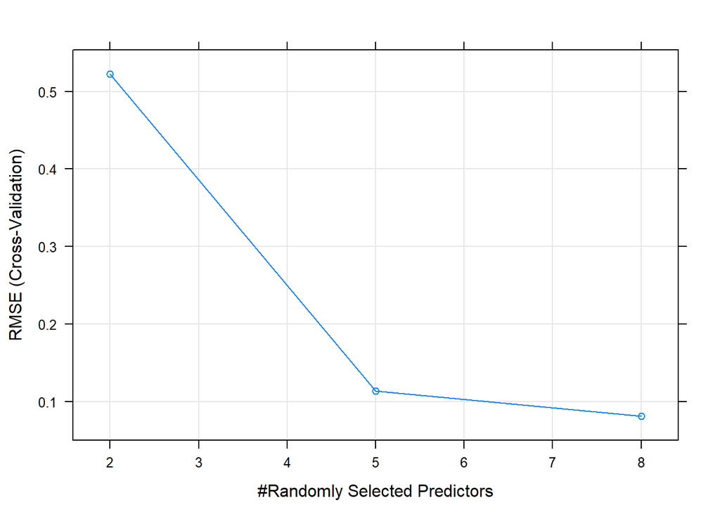

```r
plot(rfMod)
```

```r
predRF <- predict(rfMod, testingSet)

predDF <- data.frame(predRF, type=testingSet$incrDaysThisCycle)
predDF
```

```
##                   predRF type
## 2005-09-28 -7.084999e-15    0
## 2005-10-07  1.000000e+00    1
## 2005-10-10  1.000000e+00    1
## 2005-10-14  1.000000e+00    1
## 2005-10-19 -7.199574e-15    0
## 2005-10-21  2.000000e+00    2
## 2005-10-24  2.000000e+00    2
## 2005-10-28  1.500000e+01   15
## 2005-11-14  1.498000e+01   15
## 2005-11-16  1.000000e+00    1
## 2005-11-22  2.000000e+00    2
## 2005-11-23  1.996000e+00    2
## 2005-12-06  2.000000e+00    2
## 2005-12-12 -6.998846e-15    0
## 2005-12-13  7.271067e+00    8
## 2005-12-14  7.104700e+00    8
## 2005-12-16  7.192200e+00    8
## 2005-12-23  7.740333e+00    8
## 2005-12-27 -7.586820e-15    0
## 2005-12-29 -7.373657e-15    0
## 2006-01-05  3.000000e+00    3
## 2006-01-06 -8.482992e-15    0
## 2006-01-09 -7.008616e-15    0
## 2006-01-19 -7.406520e-15    0
## 2006-01-23  2.000000e+00    2
## 2006-01-24  2.000000e+00    2
## 2006-01-26 -7.410073e-15    0
## 2006-01-27  3.994000e+00    4
## 2006-02-01  4.000000e+00    4
## 2006-02-03 -8.451906e-15    0
## 2006-02-07  2.000000e+00    2
## 2006-02-10  3.000000e+00    3
## 2006-02-15  3.000000e+00    3
## 2006-03-03 -8.459011e-15    0
## 2006-03-09  1.000000e+00    1
## 2006-03-20  7.740233e+00    7
## 2006-03-24  1.000000e+00    1
## 2006-03-28  1.000000e+00    1
## 2006-03-29  1.000000e+00    1
```

[output cut: 1036 more lines]

```
## 2020-01-22  2.000000e+00    2
## 2020-01-23  2.000000e+00    2
## 2020-01-27  1.000000e+00    1
## 2020-02-07  4.000000e+00    4
## 2020-02-13 -7.418066e-15    0
## 2020-02-14 -8.444800e-15    0
## 2020-02-18 -7.589485e-15    0
## 2020-02-21 -8.467893e-15    0
## 2020-02-24 -6.983747e-15    0
## 2020-02-25 -7.485568e-15    0
## 2020-02-27 -7.340795e-15    0
## 2020-03-06 -8.490986e-15    0
## 2020-03-09  1.000000e+00    1
## 2020-03-11 -7.155165e-15    0
## 2020-03-12  1.000000e+00    1
```

```r
sum <- sum(predRF==testingSet$incrDaysThisCycle)
length <- length(testingSet$incrDaysThisCycle)
accuracy_rfMod <- (sum/length)
accuracy_rfMod
```

```
## [1] 0.459633
```

```r
results <- c(round(accuracy_rfMod,2), round(100,2))
results <- as.factor(results)
results <- t(data.frame(results))

colnames(results) <- colnames(predDF)
Results <- rbind(predDF, results)
Results
```

```
##                           predRF type
## 2005-09-28  -7.0849992539479e-15    0
## 2005-10-07                     1    1
## 2005-10-10                     1    1
## 2005-10-14                     1    1
## 2005-10-19 -7.19957427008922e-15    0
## 2005-10-21                     2    2
## 2005-10-24                     2    2
## 2005-10-28                    15   15
## 2005-11-14                 14.98   15
## 2005-11-16                     1    1
## 2005-11-22                     2    2
## 2005-11-23                 1.996    2
## 2005-12-06                     2    2
## 2005-12-12 -6.99884594723699e-15    0
## 2005-12-13      7.27106666666667    8
## 2005-12-14                7.1047    8
## 2005-12-16                7.1922    8
## 2005-12-23      7.74033333333333    8
## 2005-12-27 -7.58682006107847e-15    0
## 2005-12-29 -7.37365724035044e-15    0
## 2006-01-05                     3    3
## 2006-01-06  -8.4829920865559e-15    0
## 2006-01-09 -7.00861590985369e-15    0
## 2006-01-19 -7.40651984187934e-15    0
## 2006-01-23                     2    2
## 2006-01-24                     2    2
## 2006-01-26 -7.41007255555814e-15    0
## 2006-01-27                 3.994    4
## 2006-02-01                     4    4
## 2006-02-03 -8.45190584186639e-15    0
## 2006-02-07                     2    2
## 2006-02-10                     3    3
## 2006-02-15                     3    3
## 2006-03-03 -8.45901126922399e-15    0
## 2006-03-09                     1    1
## 2006-03-20      7.74023333333333    7
## 2006-03-24                     1    1
## 2006-03-28                     1    1
## 2006-03-29                     1    1
```

[output cut: 1037 more lines]

```
## 2020-01-23                     2    2
## 2020-01-27                     1    1
## 2020-02-07                     4    4
## 2020-02-13 -7.41806616133545e-15    0
## 2020-02-14 -8.44480041450879e-15    0
## 2020-02-18 -7.58948459633757e-15    0
## 2020-02-21 -8.46789305342099e-15    0
## 2020-02-24 -6.98374691410209e-15    0
## 2020-02-25 -7.48556772123266e-15    0
## 2020-02-27 -7.34079463882154e-15    0
## 2020-03-06  -8.4909856923332e-15    0
## 2020-03-09                     1    1
## 2020-03-11 -7.15516534910421e-15    0
## 2020-03-12                     1    1
## results                     0.46  100
```

```r
knnMod <- train(incrDaysThisCycle ~ .,
                method='knn', preProcess=c('center','scale'),
                tuneLength=10, trControl=trainControl(method='cv'), data=trainingSet)
```

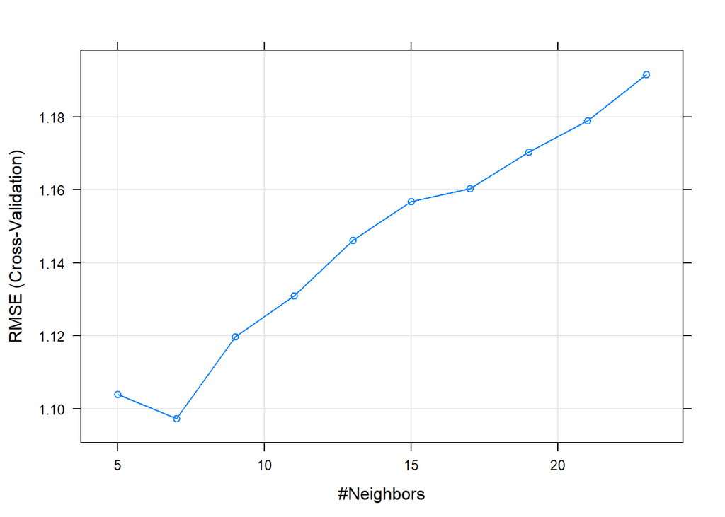

```r
plot(knnMod)
```

```r
rpartMod <- train(incrDaysThisCycle ~ ., method='rpart', tuneLength=9, data=trainingSet)
```

```r
glmMod <- train(incrDaysThisCycle ~ .,
                method='glm', data=trainingSet)
```

```r
predKNN <- predict(knnMod, testingSet)
predRPART <- predict(rpartMod, testingSet)
```

```r
predGLM <- predict(glmMod, testingSet)
```

```r
length=length(testingSet$incrDaysThisCycle)
```

```r
sumKNN <- sum(predKNN==testingSet$incrDaysThisCycle)
sumRPart <- sum(predRPART==testingSet$incrDaysThisCycle)
```

```r
sumGLM <- sum(predGLM==testingSet$incrDaysThisCycle)
```

```r
accuracy_KNN <- sumKNN/length
accuracy_RPART <- sumRPart/length
```

```r
accuracy_GLM <- sumGLM/length
```

```r
predDF2 <- data.frame(predRF,predKNN,predRPART,predGLM,
                      TYPE=testingSet$incrDaysThisCycle)
colnames(predDF2) <- c('RandomForest','KNN','Rpart','GLM','TrueValue')

results <- c(round(accuracy_rfMod,2),
             round(accuracy_KNN,2),
             round(accuracy_RPART,2),
             round(accuracy_GLM,2),
             round(100,2))

results <- as.factor(results)
results <- t(data.frame(results))
colnames(results) <- c('RandomForest','KNN','Rpart','GLM','TrueValue')
Results <- rbind(predDF2, results)
Results
```

```
##                     RandomForest               KNN            Rpart
## 2005-09-28  -7.0849992539479e-15 0.142857142857143                0
## 2005-10-07                     1  1.14285714285714                1
## 2005-10-10                     1  1.28571428571429                1
## 2005-10-14                     1  1.28571428571429                1
## 2005-10-19 -7.19957427008922e-15                 0                0
## 2005-10-21                     2  2.85714285714286                2
## 2005-10-24                     2  2.42857142857143                2
## 2005-10-28                    15                 5             14.4
## 2005-11-14                 14.98  5.28571428571429             14.4
## 2005-11-16                     1                 1                1
## 2005-11-22                     2                 2                2
## 2005-11-23                 1.996                 2                2
## 2005-12-06                     2  2.57142857142857                2
## 2005-12-12 -6.99884594723699e-15                 0                0
## 2005-12-13      7.27106666666667  6.71428571428571 6.56198347107438
## 2005-12-14                7.1047  5.42857142857143 6.56198347107438
## 2005-12-16                7.1922  5.85714285714286 6.56198347107438
## 2005-12-23      7.74033333333333  7.14285714285714 6.56198347107438
## 2005-12-27 -7.58682006107847e-15                 0                0
## 2005-12-29 -7.37365724035044e-15                 0                0
## 2006-01-05                     3  3.42857142857143                3
## 2006-01-06  -8.4829920865559e-15                 0                0
## 2006-01-09 -7.00861590985369e-15                 0                0
## 2006-01-19 -7.40651984187934e-15                 0                0
## 2006-01-23                     2  2.28571428571429                2
## 2006-01-24                     2  2.71428571428571                2
## 2006-01-26 -7.41007255555814e-15                 0                0
## 2006-01-27                 3.994  3.28571428571429 4.37091988130564
## 2006-02-01                     4  4.28571428571429 4.37091988130564
## 2006-02-03 -8.45190584186639e-15                 0                0
## 2006-02-07                     2  2.14285714285714                2
## 2006-02-10                     3  2.71428571428571                3
## 2006-02-15                     3  2.85714285714286                3
## 2006-03-03 -8.45901126922399e-15                 0                0
## 2006-03-09                     1                 1                1
## 2006-03-20      7.74023333333333                 5 6.56198347107438
## 2006-03-24                     1                 1                1
## 2006-03-28                     1                 1                1
## 2006-03-29                     1                 1                1
```

[output cut: 2129 more lines]

```
## 2020-01-23   3.03686882695058         2
## 2020-01-27   1.91471690880944         1
## 2020-02-07   3.75303066208382         4
## 2020-02-13 -0.513667948306208         0
## 2020-02-14 -0.546345408504741         0
## 2020-02-18 -0.592840407011948         0
## 2020-02-21 -0.541111639610385         0
## 2020-02-24 -0.727034990314399         0
## 2020-02-25  -0.66354204328549         0
## 2020-02-27 -0.571966805408699         0
## 2020-03-06 -0.550924710832838         0
## 2020-03-09    1.9284347202075         1
## 2020-03-11 -0.542236314808473         0
## 2020-03-12   2.03902518059881         1
## results                     0       100
```

When looking at the above table, the errors are based on an exact match, but the values you notice as I do, are rounded up to the true value if greater than zero and zero if less than zero will give very near perfect results for predicting the number of days the cycle will be increasing. Lets test this out.

```r
predRF_round <- predict(rfMod, testingSet)

predRF_round <- ifelse(predRF_round<0,0,round(predRF,0))

predDF_round <- data.frame(predRF_round, IncreasingDaysThisCycle=testingSet$incrDaysThisCycle)
predDF_round
```

```
##            predRF_round IncreasingDaysThisCycle
## 2005-09-28            0                       0
## 2005-10-07            1                       1
## 2005-10-10            1                       1
## 2005-10-14            1                       1
## 2005-10-19            0                       0
## 2005-10-21            2                       2
## 2005-10-24            2                       2
## 2005-10-28           15                      15
## 2005-11-14           15                      15
## 2005-11-16            1                       1
## 2005-11-22            2                       2
## 2005-11-23            2                       2
## 2005-12-06            2                       2
## 2005-12-12            0                       0
## 2005-12-13            7                       8
## 2005-12-14            7                       8
## 2005-12-16            7                       8
## 2005-12-23            8                       8
## 2005-12-27            0                       0
## 2005-12-29            0                       0
## 2006-01-05            3                       3
## 2006-01-06            0                       0
## 2006-01-09            0                       0
## 2006-01-19            0                       0
## 2006-01-23            2                       2
## 2006-01-24            2                       2
## 2006-01-26            0                       0
## 2006-01-27            4                       4
## 2006-02-01            4                       4
## 2006-02-03            0                       0
## 2006-02-07            2                       2
## 2006-02-10            3                       3
## 2006-02-15            3                       3
## 2006-03-03            0                       0
## 2006-03-09            1                       1
## 2006-03-20            8                       7
## 2006-03-24            1                       1
## 2006-03-28            1                       1
## 2006-03-29            1                       1
```

[output cut: 1036 more lines]

```
## 2020-01-22            2                       2
## 2020-01-23            2                       2
## 2020-01-27            1                       1
## 2020-02-07            4                       4
## 2020-02-13            0                       0
## 2020-02-14            0                       0
## 2020-02-18            0                       0
## 2020-02-21            0                       0
## 2020-02-24            0                       0
## 2020-02-25            0                       0
## 2020-02-27            0                       0
## 2020-03-06            0                       0
## 2020-03-09            1                       1
## 2020-03-11            0                       0
## 2020-03-12            1                       1
```

```r
sum <- sum(predRF_round==testingSet$incrDaysThisCycle)
length <- length(testingSet$incrDaysThisCycle)
accuracy_rfMod_round <- (sum/length)
accuracy_rfMod_round
```

```
## [1] 0.9889908
```

```r
results_round <- c(round(accuracy_rfMod_round,2), round(100,2))
results_round <- as.factor(results_round)
results_round <- t(data.frame(results_round))

colnames(results_round) <- colnames(predDF_round)
Results_round <- rbind(predDF_round, results_round)
Results_round
```

```
##               predRF_round IncreasingDaysThisCycle
## 2005-09-28               0                       0
## 2005-10-07               1                       1
## 2005-10-10               1                       1
## 2005-10-14               1                       1
## 2005-10-19               0                       0
## 2005-10-21               2                       2
## 2005-10-24               2                       2
## 2005-10-28              15                      15
## 2005-11-14              15                      15
## 2005-11-16               1                       1
## 2005-11-22               2                       2
## 2005-11-23               2                       2
## 2005-12-06               2                       2
## 2005-12-12               0                       0
## 2005-12-13               7                       8
## 2005-12-14               7                       8
## 2005-12-16               7                       8
## 2005-12-23               8                       8
## 2005-12-27               0                       0
## 2005-12-29               0                       0
## 2006-01-05               3                       3
## 2006-01-06               0                       0
## 2006-01-09               0                       0
## 2006-01-19               0                       0
## 2006-01-23               2                       2
## 2006-01-24               2                       2
## 2006-01-26               0                       0
## 2006-01-27               4                       4
## 2006-02-01               4                       4
## 2006-02-03               0                       0
## 2006-02-07               2                       2
## 2006-02-10               3                       3
## 2006-02-15               3                       3
## 2006-03-03               0                       0
## 2006-03-09               1                       1
## 2006-03-20               8                       7
## 2006-03-24               1                       1
## 2006-03-28               1                       1
## 2006-03-29               1                       1
```

[output cut: 1037 more lines]

```
## 2020-01-23               2                       2
## 2020-01-27               1                       1
## 2020-02-07               4                       4
## 2020-02-13               0                       0
## 2020-02-14               0                       0
## 2020-02-18               0                       0
## 2020-02-21               0                       0
## 2020-02-24               0                       0
## 2020-02-25               0                       0
## 2020-02-27               0                       0
## 2020-03-06               0                       0
## 2020-03-09               1                       1
## 2020-03-11               0                       0
## 2020-03-12               1                       1
## results_round         0.99                     100
```

```r
knnMod_round <- train(incrDaysThisCycle ~ .,
                method='knn', preProcess=c('center','scale'),
                tuneLength=10, trControl=trainControl(method='cv'), data=trainingSet)
```

```r
rpartMod_round <- train(incrDaysThisCycle ~ ., method='rpart', tuneLength=9, data=trainingSet)
```

```r
glmMod_round <- train(incrDaysThisCycle ~ .,
                method='glm', data=trainingSet)
```

```r
predKNN <- predict(knnMod_round, testingSet)
predKNN_round <- ifelse(predKNN<0,0,round(predKNN,0))

predRPART <- predict(rpartMod_round, testingSet)
predRPART_round <- ifelse(predRPART<0,0,round(predRPART,0))
```

```r
predGLM <- predict(glmMod_round, testingSet)
predGLM_round <- ifelse(predGLM<0,0,round(predGLM,0))
```

```r
length=length(testingSet$incrDaysThisCycle)
```

```r
sumKNN_round <- sum(predKNN_round==testingSet$incrDaysThisCycle)
sumRPart_round <- sum(predRPART_round==testingSet$incrDaysThisCycle)
```

```r
sumGLM_round <- sum(predGLM_round==testingSet$incrDaysThisCycle)
```

```r
accuracy_KNN_round <- sumKNN_round/length
accuracy_RPART_round <- sumRPart_round/length
```

```r
accuracy_GLM_round <- sumGLM_round/length
```

```r
predDF2_round <- data.frame(predRF_round,predKNN_round,predRPART_round,predGLM_round,
                      IncreasingDaysThisCycle=testingSet$incrDaysThisCycle)
colnames(predDF2_round) <- c('RandomForest_round','KNN_round','Rpart_round','GLM_round','IncreasingDaysThisCycle')

results_round <- c(round(accuracy_rfMod_round,2),
             round(accuracy_KNN_round,2),
             round(accuracy_RPART_round,2),
             round(accuracy_GLM_round,2),
             round(100,2))

results_round <- as.factor(results_round)
results_round <- t(data.frame(results_round))
colnames(results_round) <- c('RandomForest_round','KNN_round','Rpart_round','GLM_round','IncreasingDaysThisCycle')
Results_round <- rbind(predDF2_round, results_round)
Results_round
```

```
##               RandomForest_round KNN_round Rpart_round GLM_round
## 2005-09-28                     0         0           0         0
## 2005-10-07                     1         1           1         2
## 2005-10-10                     1         1           1         2
## 2005-10-14                     1         1           1         2
## 2005-10-19                     0         0           0         0
## 2005-10-21                     2         3           2         3
## 2005-10-24                     2         2           2         3
## 2005-10-28                    15         5          14         4
## 2005-11-14                    15         5          14         4
## 2005-11-16                     1         1           1         2
## 2005-11-22                     2         2           2         3
## 2005-11-23                     2         2           2         3
## 2005-12-06                     2         3           2         3
## 2005-12-12                     0         0           0         0
## 2005-12-13                     7         7           7         4
## 2005-12-14                     7         5           7         4
## 2005-12-16                     7         6           7         4
## 2005-12-23                     8         7           7         4
## 2005-12-27                     0         0           0         0
## 2005-12-29                     0         0           0         0
## 2006-01-05                     3         3           3         4
## 2006-01-06                     0         0           0         0
## 2006-01-09                     0         0           0         0
## 2006-01-19                     0         0           0         0
## 2006-01-23                     2         2           2         3
## 2006-01-24                     2         3           2         3
## 2006-01-26                     0         0           0         0
## 2006-01-27                     4         3           4         4
## 2006-02-01                     4         4           4         4
## 2006-02-03                     0         0           0         0
## 2006-02-07                     2         2           2         3
## 2006-02-10                     3         3           3         3
## 2006-02-15                     3         3           3         4
## 2006-03-03                     0         0           0         0
## 2006-03-09                     1         1           1         2
## 2006-03-20                     8         5           7         4
## 2006-03-24                     1         1           1         2
## 2006-03-28                     1         1           1         2
## 2006-03-29                     1         1           1         2
```

[output cut: 2129 more lines]

```
## 2020-01-23                          2
## 2020-01-27                          1
## 2020-02-07                          4
## 2020-02-13                          0
## 2020-02-14                          0
## 2020-02-18                          0
## 2020-02-21                          0
## 2020-02-24                          0
## 2020-02-25                          0
## 2020-02-27                          0
## 2020-03-06                          0
## 2020-03-09                          1
## 2020-03-11                          0
## 2020-03-12                          1
## results_round                     100
```

Lets compare this to the table we just saw earlier when the values weren’t rounded or zero if less than zero.

```r
Results
```

```
##                     RandomForest               KNN            Rpart
## 2005-09-28  -7.0849992539479e-15 0.142857142857143                0
## 2005-10-07                     1  1.14285714285714                1
## 2005-10-10                     1  1.28571428571429                1
## 2005-10-14                     1  1.28571428571429                1
## 2005-10-19 -7.19957427008922e-15                 0                0
## 2005-10-21                     2  2.85714285714286                2
## 2005-10-24                     2  2.42857142857143                2
## 2005-10-28                    15                 5             14.4
## 2005-11-14                 14.98  5.28571428571429             14.4
## 2005-11-16                     1                 1                1
## 2005-11-22                     2                 2                2
## 2005-11-23                 1.996                 2                2
## 2005-12-06                     2  2.57142857142857                2
## 2005-12-12 -6.99884594723699e-15                 0                0
## 2005-12-13      7.27106666666667  6.71428571428571 6.56198347107438
## 2005-12-14                7.1047  5.42857142857143 6.56198347107438
## 2005-12-16                7.1922  5.85714285714286 6.56198347107438
## 2005-12-23      7.74033333333333  7.14285714285714 6.56198347107438
## 2005-12-27 -7.58682006107847e-15                 0                0
## 2005-12-29 -7.37365724035044e-15                 0                0
## 2006-01-05                     3  3.42857142857143                3
## 2006-01-06  -8.4829920865559e-15                 0                0
## 2006-01-09 -7.00861590985369e-15                 0                0
## 2006-01-19 -7.40651984187934e-15                 0                0
## 2006-01-23                     2  2.28571428571429                2
## 2006-01-24                     2  2.71428571428571                2
## 2006-01-26 -7.41007255555814e-15                 0                0
## 2006-01-27                 3.994  3.28571428571429 4.37091988130564
## 2006-02-01                     4  4.28571428571429 4.37091988130564
## 2006-02-03 -8.45190584186639e-15                 0                0
## 2006-02-07                     2  2.14285714285714                2
## 2006-02-10                     3  2.71428571428571                3
## 2006-02-15                     3  2.85714285714286                3
## 2006-03-03 -8.45901126922399e-15                 0                0
## 2006-03-09                     1                 1                1
## 2006-03-20      7.74023333333333                 5 6.56198347107438
## 2006-03-24                     1                 1                1
## 2006-03-28                     1                 1                1
## 2006-03-29                     1                 1                1
```

[output cut: 2129 more lines]

```
## 2020-01-23   3.03686882695058         2
## 2020-01-27   1.91471690880944         1
## 2020-02-07   3.75303066208382         4
## 2020-02-13 -0.513667948306208         0
## 2020-02-14 -0.546345408504741         0
## 2020-02-18 -0.592840407011948         0
## 2020-02-21 -0.541111639610385         0
## 2020-02-24 -0.727034990314399         0
## 2020-02-25  -0.66354204328549         0
## 2020-02-27 -0.571966805408699         0
## 2020-03-06 -0.550924710832838         0
## 2020-03-09    1.9284347202075         1
## 2020-03-11 -0.542236314808473         0
## 2020-03-12   2.03902518059881         1
## results                     0       100
```

We can align the rounded table by indices with our sAAL testing set table to see what dates we can look at for clarity.

```r
sAAL_1$Date <- row.names(sAAL_1)
testingSet$Date <- row.names(testingSet)
Results_round$Date <- row.names(Results_round)

AAL_1 <- merge(testingSet,Results_round, by.x='Date', by.y='Date')
tbl <- rbind(head(AAL_1),tail(AAL_1))
tbl
```

```
##            Date DayOfWeek stockDayValue  lag1 today2lag1 incrDaysThisCycle
## 1    2005-09-28 Wednesday         20.50 19.30  1.0621762                 0
## 2    2005-10-07    Friday         22.15 22.58  0.9809566                 1
## 3    2005-10-10    Monday         22.21 22.15  1.0027088                 1
## 4    2005-10-14    Friday         22.27 21.71  1.0257946                 1
## 5    2005-10-19 Wednesday         21.38 21.49  0.9948813                 0
## 6    2005-10-21    Friday         21.96 21.02  1.0447193                 2
## 1085 2020-02-25   Tuesday         23.12 25.45  0.9084479                 0
## 1086 2020-02-27  Thursday         20.60 22.31  0.9233528                 0
## 1087 2020-03-06    Friday         15.97 16.04  0.9956358                 0
## 1088 2020-03-09    Monday         14.75 15.97  0.9236068                 1
## 1089 2020-03-11 Wednesday         16.26 17.00  0.9564706                 0
## 1090 2020-03-12  Thursday         13.45 16.26  0.8271833                 1
##      nTimesIncrDayCountsOccurs RandomForest_round KNN_round Rpart_round
## 1                          955                  0         0           0
```

[output cut: 24 more lines]

```r
Results_round$RandomForest_round <-
  as.numeric(paste(Results_round$RandomForest_round))
Results_round$KNN_round <-
  as.numeric(paste(Results_round$KNN_round))
Results_round$Rpart_round <-
  as.numeric(paste(Results_round$Rpart_round))
Results_round$GLM_round <-
  as.numeric(paste(Results_round$GLM_round))
Results_round$IncreasingDaysThisCycle <-
  as.numeric(paste(Results_round$IncreasingDaysThisCycle))



Results_round$mostVoted <- ifelse(
                        (Results_round$RandomForest_round==Results_round$KNN_round |                        Results_round$RandomForest_round==Results_round$Rpart_round |                        Results_round$RandomForest_round==Results_round$GLM_round),

ifelse(Results_round$KNN_round==Results_round$Rpart_round |                           Results_round$KNN_round==Results_round$GLM_round,
        Results_round$RandomForest_round,
        ifelse(Results_round$Rpart_round ==Results_round$GLM_round,
               Results_round$Rpart_round,
               Results_round$RandomForest_round)),
                               ifelse(Results_round$KNN_round==Results_round$Rpart_round |                          Results_round$KNN_round==Results_round$GLM_round,
        Results_round$KNN_round,
        ifelse(Results_round$Rpart_round==Results_round$GLM_round,
               Results_round$Rpart_round,
               ifelse(Results_round$Rpart_round>Results_round$RandomForest_round,
                      Results_round$Rpart_round,
                      Results_round$RandomForest_round))
      )
)

sMost <- sum(Results_round$mostVoted==Results_round$IncreasingDaysThisCycle)
lMost <- length(Results_round$IncreasingDaysThisCycle)-1
accMost <- sMost/lMost
```

Lets run these rounded models on the training set too, to then combine the predicted results of the training and testing models.

```r
predRF_round1 <- predict(rfMod, trainingSet)

predRF_round1 <- ifelse(predRF_round1<0,0,round(predRF,0))

predDF_round1 <- data.frame(predRF_round1, IncreasingDaysThisCycle=trainingSet$incrDaysThisCycle)
predDF_round1
```

```
##            predRF_round1 IncreasingDaysThisCycle
## 2005-09-29             0                       5
## 2005-09-30             1                       5
## 2005-10-03             1                       5
## 2005-10-04             1                       5
## 2005-10-05             0                       5
## 2005-10-06             2                       5
## 2005-10-11             0                       0
## 2005-10-12             0                       0
## 2005-10-13            15                       1
## 2005-10-17             0                       0
## 2005-10-18             0                       0
## 2005-10-20             2                       2
## 2005-10-25             2                      15
## 2005-10-26             0                      15
## 2005-10-27             7                      15
## 2005-10-31             7                      15
## 2005-11-01             7                      15
## 2005-11-02             8                      15
## 2005-11-03             0                      15
## 2005-11-04             0                      15
## 2005-11-07             3                      15
## 2005-11-08             0                      15
## 2005-11-09             0                      15
## 2005-11-10             0                      15
## 2005-11-11             2                      15
## 2005-11-15             2                      15
## 2005-11-17             0                       1
## 2005-11-18             0                       0
## 2005-11-21             4                       2
## 2005-11-25             0                       1
## 2005-11-28             2                       1
## 2005-11-29             3                       2
## 2005-11-30             3                       2
## 2005-12-01             0                       2
## 2005-12-02             0                       0
## 2005-12-05             8                       2
## 2005-12-07             1                       2
## 2005-12-08             1                       1
## 2005-12-09             1                       1
```

[output cut: 2495 more lines]

```
## 2020-02-05             0                       3
## 2020-02-06             1                       4
## 2020-02-10             1                       4
## 2020-02-11             0                       4
## 2020-02-12             2                       4
## 2020-02-19             2                       1
## 2020-02-20             1                       1
## 2020-02-26             0                       0
## 2020-02-28             0                       0
## 2020-03-02             0                       0
## 2020-03-03             1                       1
## 2020-03-04             1                       1
## 2020-03-05             0                       0
## 2020-03-10             1                       1
## 2020-03-13             4                       1
```

```r
sum <- sum(predRF_round1==trainingSet$incrDaysThisCycle)
length <- length(trainingSet$incrDaysThisCycle)
accuracy_rfMod_round1 <- (sum/length)
accuracy_rfMod_round1
```

```
## [1] 0.3652413
```

```r
results_round1 <- c(round(accuracy_rfMod_round1,2), round(100,2))
results_round1 <- as.factor(results_round1)
results_round1 <- t(data.frame(results_round1))

colnames(results_round1) <- colnames(predDF_round1)
Results_round1 <- rbind(predDF_round1, results_round1)

Results_round1
```

```
##                predRF_round1 IncreasingDaysThisCycle
## 2005-09-29                 0                       5
## 2005-09-30                 1                       5
## 2005-10-03                 1                       5
## 2005-10-04                 1                       5
## 2005-10-05                 0                       5
## 2005-10-06                 2                       5
## 2005-10-11                 0                       0
## 2005-10-12                 0                       0
## 2005-10-13                15                       1
## 2005-10-17                 0                       0
## 2005-10-18                 0                       0
## 2005-10-20                 2                       2
## 2005-10-25                 2                      15
## 2005-10-26                 0                      15
## 2005-10-27                 7                      15
## 2005-10-31                 7                      15
## 2005-11-01                 7                      15
## 2005-11-02                 8                      15
## 2005-11-03                 0                      15
## 2005-11-04                 0                      15
## 2005-11-07                 3                      15
## 2005-11-08                 0                      15
## 2005-11-09                 0                      15
## 2005-11-10                 0                      15
## 2005-11-11                 2                      15
## 2005-11-15                 2                      15
## 2005-11-17                 0                       1
## 2005-11-18                 0                       0
## 2005-11-21                 4                       2
## 2005-11-25                 0                       1
## 2005-11-28                 2                       1
## 2005-11-29                 3                       2
## 2005-11-30                 3                       2
## 2005-12-01                 0                       2
## 2005-12-02                 0                       0
## 2005-12-05                 8                       2
## 2005-12-07                 1                       2
## 2005-12-08                 1                       1
## 2005-12-09                 1                       1
```

[output cut: 2496 more lines]

```
## 2020-02-06                 1                       4
## 2020-02-10                 1                       4
## 2020-02-11                 0                       4
## 2020-02-12                 2                       4
## 2020-02-19                 2                       1
## 2020-02-20                 1                       1
## 2020-02-26                 0                       0
## 2020-02-28                 0                       0
## 2020-03-02                 0                       0
## 2020-03-03                 1                       1
## 2020-03-04                 1                       1
## 2020-03-05                 0                       0
## 2020-03-10                 1                       1
## 2020-03-13                 4                       1
## results_round1          0.37                     100
```

```r
knnMod_round1 <- train(incrDaysThisCycle ~ .,
                method='knn', preProcess=c('center','scale'),
                tuneLength=10, trControl=trainControl(method='cv'), data=trainingSet)
```

```r
rpartMod_round1 <- train(incrDaysThisCycle ~ ., method='rpart', tuneLength=9, data=trainingSet)
```

```r
glmMod_round1 <- train(incrDaysThisCycle ~ .,
                method='glm', data=trainingSet)
```

```r
predKNN <- predict(knnMod_round1, trainingSet)
predKNN_round1 <- ifelse(predKNN<0,0,round(predKNN,0))

predRPART <- predict(rpartMod_round1, trainingSet)
predRPART_round1 <- ifelse(predRPART<0,0,round(predRPART,0))
```

```r
predGLM <- predict(glmMod_round1, trainingSet)
predGLM_round1 <- ifelse(predGLM<0,0,round(predGLM,0))
```

```r
length=length(trainingSet$incrDaysThisCycle)
```

```r
sumKNN_round1 <- sum(predKNN_round1==trainingSet$incrDaysThisCycle)
sumRPart_round1 <- sum(predRPART_round1==trainingSet$incrDaysThisCycle)
```

```r
sumGLM_round1 <- sum(predGLM_round1==trainingSet$incrDaysThisCycle)
```

```r
accuracy_KNN_round1 <- sumKNN_round1/length
accuracy_RPART_round1 <- sumRPart_round1/length
```

```r
accuracy_GLM_round1 <- sumGLM_round1/length
```

```r
predDF2_round1 <- data.frame(predRF_round1,predKNN_round1,predRPART_round1,predGLM_round1,
                      IncreasingDaysThisCycle=trainingSet$incrDaysThisCycle)
colnames(predDF2_round1) <- c('RandomForest_round1','KNN_round1','Rpart_round1','GLM_round1','IncreasingDaysThisCycle')

results_round1 <- c(round(accuracy_rfMod_round1,2),
             round(accuracy_KNN_round1,2),
             round(accuracy_RPART_round1,2),
             round(accuracy_GLM_round1,2),
             round(100,2))

results_round1 <- as.factor(results_round1)
results_round1 <- t(data.frame(results_round1))
colnames(results_round1) <- c('RandomForest_round1','KNN_round1','Rpart_round1','GLM_round1','IncreasingDaysThisCycle')
Results_round1 <- rbind(predDF2_round1, results_round1)
Results_round1
```

```
##                RandomForest_round1 KNN_round1 Rpart_round1 GLM_round1
## 2005-09-29                       0          5            4          4
## 2005-09-30                       1          5            4          4
## 2005-10-03                       1          6            4          4
## 2005-10-04                       1          5            4          4
## 2005-10-05                       0          5            4          4
## 2005-10-06                       2          6            4          4
## 2005-10-11                       0          0            0          0
## 2005-10-12                       0          0            0          0
## 2005-10-13                      15          1            1          2
## 2005-10-17                       0          0            0          0
## 2005-10-18                       0          0            0          0
## 2005-10-20                       2          2            2          3
## 2005-10-25                       2          6           14          4
## 2005-10-26                       0          6           14          4
## 2005-10-27                       7          6           14          4
## 2005-10-31                       7          7           14          4
## 2005-11-01                       7          8           14          4
## 2005-11-02                       8          7           14          4
## 2005-11-03                       0          7           14          4
## 2005-11-04                       0          6           14          4
## 2005-11-07                       3          6           14          4
## 2005-11-08                       0          8           14          4
## 2005-11-09                       0          6           14          4
## 2005-11-10                       0          6           14          4
## 2005-11-11                       2          7           14          4
## 2005-11-15                       2          7           14          4
## 2005-11-17                       0          1            1          2
## 2005-11-18                       0          0            0          0
## 2005-11-21                       4          2            2          3
## 2005-11-25                       0          1            1          2
## 2005-11-28                       2          1            1          2
## 2005-11-29                       3          2            2          3
## 2005-11-30                       3          2            2          3
## 2005-12-01                       0          2            2          3
## 2005-12-02                       0          0            0          0
## 2005-12-05                       8          2            2          3
## 2005-12-07                       1          2            2          3
## 2005-12-08                       1          1            1          2
## 2005-12-09                       1          1            1          2
```

[output cut: 5047 more lines]

```
## 2020-02-06                           4
## 2020-02-10                           4
## 2020-02-11                           4
## 2020-02-12                           4
## 2020-02-19                           1
## 2020-02-20                           1
## 2020-02-26                           0
## 2020-02-28                           0
## 2020-03-02                           0
## 2020-03-03                           1
## 2020-03-04                           1
## 2020-03-05                           0
## 2020-03-10                           1
## 2020-03-13                           1
## results_round1                     100
```

We can align the rounded table by indices with our sAAL training set table to see what dates we can look at for clarity.

```r
sAAL_1$Date <- row.names(sAAL_1)
trainingSet$Date <- row.names(trainingSet)
Results_round1$Date <- row.names(Results_round1)

AAL_1 <- merge(trainingSet,Results_round1, by.x='Date', by.y='Date')
tbl <- rbind(head(AAL_1),tail(AAL_1))
tbl
```

```
##            Date DayOfWeek stockDayValue  lag1 today2lag1 incrDaysThisCycle
## 1    2005-09-29  Thursday         20.21 20.50  0.9858536                 5
## 2    2005-09-30    Friday         21.01 20.21  1.0395844                 5
## 3    2005-10-03    Monday         21.50 21.01  1.0233222                 5
## 4    2005-10-04   Tuesday         22.16 21.50  1.0306977                 5
## 5    2005-10-05 Wednesday         22.20 22.16  1.0018051                 5
## 6    2005-10-06  Thursday         22.58 22.20  1.0171171                 5
## 2544 2020-03-02    Monday         18.86 19.05  0.9900264                 0
## 2545 2020-03-03   Tuesday         17.85 18.86  0.9464475                 1
## 2546 2020-03-04 Wednesday         18.53 17.85  1.0380953                 1
## 2547 2020-03-05  Thursday         16.04 18.53  0.8656233                 0
## 2548 2020-03-10   Tuesday         17.00 14.75  1.1525424                 1
## 2549 2020-03-13    Friday         14.31 13.45  1.0639405                 1
##      nTimesIncrDayCountsOccurs RandomForest_round1 KNN_round1 Rpart_round1
## 1                           30                   0          5            4
```

[output cut: 24 more lines]

```r
Results_round1$RandomForest_round1 <-
  as.numeric(paste(Results_round1$RandomForest_round1))
Results_round1$KNN_round1 <-
  as.numeric(paste(Results_round1$KNN_round1))
Results_round1$Rpart_round1 <-
  as.numeric(paste(Results_round1$Rpart_round1))
Results_round1$GLM_round1 <-
  as.numeric(paste(Results_round1$GLM_round1))
Results_round1$IncreasingDaysThisCycle <-
  as.numeric(paste(Results_round1$IncreasingDaysThisCycle))


Results_round1$mostVoted <- ifelse(
                        (Results_round1$RandomForest_round1==Results_round1$KNN_round1 |                        Results_round1$RandomForest_round1==Results_round1$Rpart_round1 |                        Results_round1$RandomForest_round1==Results_round1$GLM_round1),

ifelse(Results_round1$KNN_round1==Results_round1$Rpart_round1 |                           Results_round1$KNN_round1==Results_round1$GLM_round1,
        Results_round1$RandomForest_round1,
        ifelse(Results_round1$Rpart_round1 ==Results_round1$GLM_round1,
               Results_round1$Rpart_round1,
               Results_round1$RandomForest_round1)),
                               ifelse(Results_round1$KNN_round1==Results_round1$Rpart_round1 |                          Results_round1$KNN_round1==Results_round1$GLM_round1,
        Results_round1$KNN_round1,
        ifelse(Results_round1$Rpart_round1==Results_round1$GLM_round1,
               Results_round1$Rpart_round1,
               ifelse(Results_round1$Rpart_round1>
                        Results_round1$RandomForest_round1,
                      Results_round1$Rpart_round1,
                      Results_round1$RandomForest_round1))
      )
)
```

It turns out that using the training set the model was built on to predict the number of days increasing is worse than using the set aside testing set.

The model trained on the training set and tested on the training set:

```r
tr_Results <- rbind(head(Results_round1),tail(Results_round1))
tr_Results
```

```
##                RandomForest_round1 KNN_round1 Rpart_round1 GLM_round1
## 2005-09-29                    0.00       5.00         4.00       4.00
## 2005-09-30                    1.00       5.00         4.00       4.00
## 2005-10-03                    1.00       6.00         4.00       4.00
## 2005-10-04                    1.00       5.00         4.00       4.00
## 2005-10-05                    0.00       5.00         4.00       4.00
## 2005-10-06                    2.00       6.00         4.00       4.00
## 2020-03-03                    1.00       1.00         1.00       2.00
## 2020-03-04                    1.00       1.00         1.00       2.00
## 2020-03-05                    0.00       0.00         0.00       0.00
## 2020-03-10                    1.00       2.00         1.00       2.00
## 2020-03-13                    4.00       1.00         1.00       2.00
## results_round1                0.37       0.81         0.91       0.45
##                IncreasingDaysThisCycle           Date mostVoted
## 2005-09-29                           5     2005-09-29      4.00
## 2005-09-30                           5     2005-09-30      4.00
## 2005-10-03                           5     2005-10-03      4.00
## 2005-10-04                           5     2005-10-04      4.00
## 2005-10-05                           5     2005-10-05      4.00
## 2005-10-06                           5     2005-10-06      4.00
## 2020-03-03                           1     2020-03-03      1.00
## 2020-03-04                           1     2020-03-04      1.00
## 2020-03-05                           0     2020-03-05      0.00
## 2020-03-10                           1     2020-03-10      1.00
## 2020-03-13                           1     2020-03-13      1.00
## results_round1                     100 results_round1      0.91
```

The model trained on the training set and tested on the testing set:

```r
te_Results <- rbind(head(Results_round), tail(Results_round))
te_Results
```

```
##               RandomForest_round KNN_round Rpart_round GLM_round
## 2005-09-28                  0.00       0.0        0.00      0.00
## 2005-10-07                  1.00       1.0        1.00      2.00
## 2005-10-10                  1.00       1.0        1.00      2.00
## 2005-10-14                  1.00       1.0        1.00      2.00
## 2005-10-19                  0.00       0.0        0.00      0.00
## 2005-10-21                  2.00       3.0        2.00      3.00
## 2020-02-27                  0.00       0.0        0.00      0.00
## 2020-03-06                  0.00       0.0        0.00      0.00
## 2020-03-09                  1.00       2.0        1.00      2.00
## 2020-03-11                  0.00       0.0        0.00      0.00
## 2020-03-12                  1.00       1.0        1.00      2.00
## results_round               0.99       0.8        0.91      0.45
##               IncreasingDaysThisCycle          Date mostVoted
## 2005-09-28                          0    2005-09-28      0.00
## 2005-10-07                          1    2005-10-07      1.00
## 2005-10-10                          1    2005-10-10      1.00
## 2005-10-14                          1    2005-10-14      1.00
## 2005-10-19                          0    2005-10-19      0.00
## 2005-10-21                          2    2005-10-21      2.00
## 2020-02-27                          0    2020-02-27      0.00
## 2020-03-06                          0    2020-03-06      0.00
## 2020-03-09                          1    2020-03-09      1.00
## 2020-03-11                          0    2020-03-11      0.00
## 2020-03-12                          1    2020-03-12      1.00
## results_round                     100 results_round      0.99
```

It is the same model that takes the best model results by most voted among the four algorithms used on the training and testing sets. When the testing set was used the best model in prediction accuracy for increasing days in that cycle was random forest. And when this model was used on the training set the best model was recursive partitioned trees.

We can test out each of the 65 stocks we have records for. The stocks_65 table has the counts and groups of stock and daily stock values within the time period of that table. To modify the table to return the dates with respective counts and groups of counts within that report, the matrix_automateDateLagStocks2.Rmd file would have to have the date set in the beginning of the scipt, and ran with the number of lags or days in stock value pricing before each instance date within the time interval.It takes 10-20 minutes to produce the table csv ALL_65_stocks_countGroups_YYYY-MM-DD_YYYY_MM_DD_lagN.csv where the first ymd is the beginning of the time series and the 2nd is the date the script ran and lagN is the input number of days to lag behind each daily price ( the value N days earlier).

```r
head(stocks_65)
```

```
##   stockName
## 1       AAL
## 2       AAL
## 3       AAL
## 4       AAL
## 5       AAL
## 6       AAL
##                                                                                  stockInfo
## 1 American Airlines Group Inc. (AAL)\nNasdaqGS - NasdaqGS Real Time Price. Currency in USD
## 2 American Airlines Group Inc. (AAL)\nNasdaqGS - NasdaqGS Real Time Price. Currency in USD
## 3 American Airlines Group Inc. (AAL)\nNasdaqGS - NasdaqGS Real Time Price. Currency in USD
## 4 American Airlines Group Inc. (AAL)\nNasdaqGS - NasdaqGS Real Time Price. Currency in USD
## 5 American Airlines Group Inc. (AAL)\nNasdaqGS - NasdaqGS Real Time Price. Currency in USD
## 6 American Airlines Group Inc. (AAL)\nNasdaqGS - NasdaqGS Real Time Price. Currency in USD
##   stockExchange       Date DayOfWeek Month Year MonthYear stockDayValue
```

[output cut: 41 more lines]

```r
unique(stocks_65$stockName)
```

```
##  [1] AAL    AAP    ADDYY  AMZN   ARWR   C      COST   CVX    DLTR   EPD
## [11] F      FFIN   FTR    GOOG   HD     HMC    HOFT   HRB    HST    INO
## [21] JBLU   JNJ    JPM    JWN    KGJI   KSS    LUV    M      MGM    MSFT
## [31] NFLX   NKE    NSANY  NUS    ONCY   PCG    ROST   RRGB   S      SIG
## [41] T      TEVA   TGT    TJX    TM     UBSI   VZ     WFC    WM     WMT
## [51] WWE    XOM    AMC    ASCCY  CSSEP  FCAU   GM     GNBT   GRPN   PBYI
## [61] QSR    SCE-PB SDC    TMUS   YELP
## 65 Levels: AAL AAP ADDYY AMC AMZN ARWR ASCCY C COST CSSEP CVX DLTR EPD ... YELP
```

Go ahead and select one of the stocks in the list above and analyze where it is in a cycle of decreasing or increasing days as we did with the AAL stock.

Lets select the YELP stock, it has a limited number of observations that start March 2, 2012 through Mar 13, 2020.

```r
sYELP <- subset(stocks_65, stocks_65$stockName=='YELP')
head(sYELP)
```

```
##        stockName                                                    stockInfo
## 288866      YELP Yelp Inc. (YELP)\nNYSE - NYSE Delayed Price. Currency in USD
## 288867      YELP Yelp Inc. (YELP)\nNYSE - NYSE Delayed Price. Currency in USD
## 288868      YELP Yelp Inc. (YELP)\nNYSE - NYSE Delayed Price. Currency in USD
## 288869      YELP Yelp Inc. (YELP)\nNYSE - NYSE Delayed Price. Currency in USD
## 288870      YELP Yelp Inc. (YELP)\nNYSE - NYSE Delayed Price. Currency in USD
## 288871      YELP Yelp Inc. (YELP)\nNYSE - NYSE Delayed Price. Currency in USD
##        stockExchange       Date DayOfWeek Month Year MonthYear stockDayValue
## 288866          NYSE 2012-03-05    Monday   Mar 2012  Mar-2012         20.99
## 288867          NYSE 2012-03-06   Tuesday   Mar 2012  Mar-2012         20.50
## 288868          NYSE 2012-03-07 Wednesday   Mar 2012  Mar-2012         20.25
## 288869          NYSE 2012-03-08  Thursday   Mar 2012  Mar-2012         20.00
## 288870          NYSE 2012-03-09    Friday   Mar 2012  Mar-2012         19.80
## 288871          NYSE 2012-03-12    Monday   Mar 2012  Mar-2012         22.49
##        startDayValue startDayDate finalDayValue finalDayDate  lag1 today2lag1
```

[output cut: 34 more lines]

```r
str(sYELP)
```

```
## 'data.frame':    2020 obs. of  25 variables:
##  $ stockName                     : Factor w/ 65 levels "AAL","AAP","ADDYY",..: 65 65 65 65 65 65 65 65 65 65 ...
##  $ stockInfo                     : Factor w/ 65 levels "adidas AG (ADDYY)\nOther OTC - Other OTC Delayed Price. Currency in USD",..: 65 65 65 65 65 65 65 65 65 65 ...
##  $ stockExchange                 : Factor w/ 3 levels "Nasdaq","NYSE",..: 2 2 2 2 2 2 2 2 2 2 ...
##  $ Date                          : Factor w/ 5333 levels "1999-01-04","1999-01-05",..: 3314 3315 3316 3317 3318 3319 3320 3321 3322 3323 ...
##  $ DayOfWeek                     : Factor w/ 5 levels "Friday","Monday",..: 2 4 5 3 1 2 4 5 3 1 ...
##  $ Month                         : Factor w/ 12 levels "Apr","Aug","Dec",..: 8 8 8 8 8 8 8 8 8 8 ...
##  $ Year                          : int  2012 2012 2012 2012 2012 2012 2012 2012 2012 2012 ...
##  $ MonthYear                     : Factor w/ 255 levels "Apr-1999","Apr-2000",..: 163 163 163 163 163 163 163 163 163 163 ...
##  $ stockDayValue                 : num  21 20.5 20.2 20 19.8 ...
##  $ startDayValue                 : num  24.6 24.6 24.6 24.6 24.6 ...
##  $ startDayDate                  : Factor w/ 24 levels "1999-01-04","1999-10-19",..: 17 17 17 17 17 17 17 17 17 17 ...
##  $ finalDayValue                 : num  23.5 23.5 23.5 23.5 23.5 ...
##  $ finalDayDate                  : Factor w/ 1 level "2020-03-13": 1 1 1 1 1 1 1 1 1 1 ...
##  $ lag1                          : num  24.6 21 20.5 20.2 20 ...
##  $ today2lag1                    : num  0.854 0.977 0.988 0.988 0.99 ...
##  $ todayGrtrThanlag1             : int  0 0 0 0 0 1 1 0 0 0 ...
##  $ cumulativeSumTodayGrtrThanlag1: int  0 0 0 0 0 1 2 2 2 2 ...
##  $ nRepeatsTodayGrtrThanlag1     : int  5 5 5 5 5 1 4 4 4 4 ...
##  $ decrDaysThisCycle             : int  4 4 4 4 4 0 3 3 3 3 ...
##  $ nTimesDecrDayCountsOccurs     : int  25 25 25 25 25 485 74 74 74 74 ...
##  $ todayLessThanlag1             : int  1 1 1 1 1 0 0 1 1 1 ...
##  $ cumulativeSumTodayLessThanlag1: int  1 2 3 4 5 5 5 6 7 8 ...
##  $ nRepeatsTodayLessThanlag1     : int  1 1 1 1 3 3 3 1 1 2 ...
##  $ incrDaysThisCycle             : int  0 0 0 0 2 2 2 0 0 1 ...
##  $ nTimesIncrDayCountsOccurs     : int  494 494 494 494 131 131 131 494 494 263 ...
```

Lets change the date column to date and the year to a factor.

```r
sYELP$Date <- as.Date(sYELP$Date)
sYELP$Year <- as.factor(sYELP$Year)
```

Lets predict the number of decreasing days this cycle based on a select subset of the features displayed above.

```r
sYELP1 <- sYELP[,c(4,5,9,14,15,19,20,21,24,25)]
colnames(sYELP1)
```

```
##  [1] "Date"                      "DayOfWeek"
##  [3] "stockDayValue"             "lag1"
##  [5] "today2lag1"                "decrDaysThisCycle"
##  [7] "nTimesDecrDayCountsOccurs" "todayLessThanlag1"
##  [9] "incrDaysThisCycle"         "nTimesIncrDayCountsOccurs"
```

Lets also add a lead column that will give the next day stock value for YELP using the dplyr package. We can then see how it predicts the next day value.

```r
sYELP1$NextDayPrice <- lead(sYELP1$stockDayValue,1)
sYELP1 <- sYELP1[complete.cases(sYELP1$NextDayPrice),]
tail(sYELP1)
```

```
##              Date DayOfWeek stockDayValue  lag1 today2lag1 decrDaysThisCycle
## 290879 2020-03-05  Thursday         29.14 31.39  0.9283211                 3
## 290880 2020-03-06    Friday         28.94 29.14  0.9931367                 3
## 290881 2020-03-09    Monday         26.40 28.94  0.9122322                 3
## 290882 2020-03-10   Tuesday         27.81 26.40  1.0534091                 2
## 290883 2020-03-11 Wednesday         24.00 27.81  0.8629990                 2
## 290884 2020-03-12  Thursday         21.46 24.00  0.8941666                 2
##        nTimesDecrDayCountsOccurs todayLessThanlag1 incrDaysThisCycle
## 290879                        74                 1                 0
## 290880                        74                 1                 0
## 290881                        74                 1                 1
## 290882                       122                 0                 1
## 290883                       122                 1                 0
## 290884                       122                 1                 1
##        nTimesIncrDayCountsOccurs NextDayPrice
## 290879                       494        28.94
## 290880                       494        26.40
## 290881                       263        27.81
## 290882                       263        24.00
## 290883                       494        21.46
## 290884                       263        23.54
```

Since we used the next day price, the stock YELP doesn’t have information for the 13th of March 2020 in this data set and the table now extends through 3/12/2020. Make the row names the date and then remove the date column.

```r
row.names(sYELP1) <- as.factor(sYELP1$Date)
sYELP1 <- sYELP1[,-c(1)]
head(sYELP1)
```

```
##            DayOfWeek stockDayValue  lag1 today2lag1 decrDaysThisCycle
## 2012-03-05    Monday         20.99 24.58  0.8539463                 4
## 2012-03-06   Tuesday         20.50 20.99  0.9766556                 4
## 2012-03-07 Wednesday         20.25 20.50  0.9878049                 4
## 2012-03-08  Thursday         20.00 20.25  0.9876543                 4
## 2012-03-09    Friday         19.80 20.00  0.9899999                 4
## 2012-03-12    Monday         22.49 19.80  1.1358586                 0
##            nTimesDecrDayCountsOccurs todayLessThanlag1 incrDaysThisCycle
## 2012-03-05                        25                 1                 0
## 2012-03-06                        25                 1                 0
## 2012-03-07                        25                 1                 0
## 2012-03-08                        25                 1                 0
## 2012-03-09                        25                 1                 2
## 2012-03-12                       485                 0                 2
##            nTimesIncrDayCountsOccurs NextDayPrice
## 2012-03-05                       494        20.50
## 2012-03-06                       494        20.25
## 2012-03-07                       494        20.00
## 2012-03-08                       494        19.80
## 2012-03-09                       131        22.49
## 2012-03-12                       131        23.30
```

Now to predict the number of decreasing days, then to predict the accuracy in next day price of the stock.

```r
set.seed(12356789)

inTrain <- createDataPartition(y=sYELP1$decrDaysThisCycle, p=0.7, list=FALSE)

trainingSet <- sYELP1[inTrain,]
testingSet <- sYELP1[-inTrain,]
```

```r
rfMod <- train(decrDaysThisCycle ~ ., method='rf', data=(trainingSet),
               trControl=trainControl(method='cv'), number=5)
```

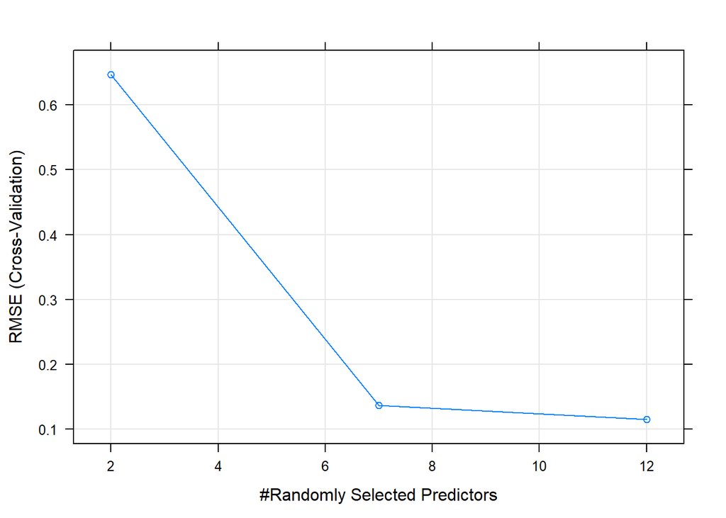

```r
plot(rfMod)
```

```r
predRF <- predict(rfMod, testingSet)

predDF <- data.frame(predRF, type=testingSet$decrDaysThisCycle)
predDF
```

```
##                   predRF type
## 2012-03-06  3.990000e+00    4
## 2012-03-09  3.982000e+00    4
## 2012-03-13  3.000000e+00    3
## 2012-03-14  3.000000e+00    3
## 2012-03-20  1.000000e+00    1
## 2012-03-23  1.000000e+00    1
## 2012-04-04  3.000000e+00    3
## 2012-04-10  1.000000e+00    1
## 2012-04-26 -1.158185e-15    0
## 2012-05-04 -1.254108e-15    0
## 2012-05-17  1.998000e+00    2
## 2012-05-21  1.006000e+00    1
## 2012-05-30  3.000000e+00    3
## 2012-06-08  1.000000e+00    1
## 2012-06-12 -8.335554e-16    0
## 2012-06-13 -9.343637e-16    0
## 2012-06-14 -9.525714e-16    0
## 2012-06-19  1.994000e+00    2
## 2012-07-02 -1.040501e-15    0
## 2012-07-10  3.998000e+00    4
## 2012-07-13  2.000000e+00    2
## 2012-07-19 -1.169287e-15    0
## 2012-07-20  4.996000e+00    5
## 2012-07-30  2.000000e+00    2
## 2012-07-31  2.000000e+00    2
## 2012-08-01  1.994000e+00    2
## 2012-08-09  1.000000e+00    1
## 2012-08-14  8.000000e+00    8
## 2012-08-17  8.000000e+00    8
## 2012-08-20  8.000000e+00    8
## 2012-08-27  1.996000e+00    2
## 2012-08-28  2.000000e+00    2
## 2012-08-29  1.000000e+00    1
## 2012-08-31 -1.259437e-15    0
## 2012-09-06  2.000000e+00    2
## 2012-09-13  2.000000e+00    2
## 2012-09-14  2.000000e+00    2
## 2012-09-18  1.996000e+00    2
## 2012-09-20 -1.303846e-15    0
```

[output cut: 551 more lines]

```
## 2019-12-16 -1.065814e-15    0
## 2019-12-17 -1.032507e-15    0
## 2020-01-03  2.998000e+00    3
## 2020-01-10 -1.007194e-15    0
## 2020-01-15  6.000000e-03    0
## 2020-01-17  2.000000e+00    2
## 2020-01-21  1.996000e+00    2
## 2020-01-22 -9.059420e-16    0
## 2020-01-29  3.004000e+00    3
## 2020-02-04 -1.090239e-15    0
## 2020-02-11 -1.012523e-15    0
## 2020-02-19  2.996000e+00    3
## 2020-02-24  2.000000e+00    2
## 2020-03-03  1.000000e+00    1
## 2020-03-04  3.000000e+00    3
```

```r
sum <- sum(predRF==testingSet$decrDaysThisCycle)
length <- length(testingSet$decrDaysThisCycle)
accuracy_rfMod <- (sum/length)
accuracy_rfMod
```

```
## [1] 0.3008264
```

```r
results <- c(round(accuracy_rfMod,2), round(100,2))
results <- as.factor(results)
results <- t(data.frame(results))

colnames(results) <- colnames(predDF)
Results <- rbind(predDF, results)
Results
```

```
##                           predRF type
## 2012-03-06                  3.99    4
## 2012-03-09                 3.982    4
## 2012-03-13                     3    3
## 2012-03-14                     3    3
## 2012-03-20                     1    1
## 2012-03-23                     1    1
## 2012-04-04                     3    3
## 2012-04-10                     1    1
## 2012-04-26 -1.15818465928896e-15    0
## 2012-05-04 -1.25410792861658e-15    0
## 2012-05-17                 1.998    2
## 2012-05-21                 1.006    1
## 2012-05-30                     3    3
## 2012-06-08                     1    1
## 2012-06-12 -8.33555446888568e-16    0
## 2012-06-13 -9.34363697524532e-16    0
## 2012-06-14 -9.52571355128384e-16    0
## 2012-06-19                 1.994    2
## 2012-07-02  -1.0405010186787e-15    0
## 2012-07-10                 3.998    4
## 2012-07-13                     2    2
## 2012-07-19 -1.16928688953521e-15    0
## 2012-07-20                 4.996    5
## 2012-07-30                     2    2
## 2012-07-31                     2    2
## 2012-08-01                 1.994    2
## 2012-08-09                     1    1
## 2012-08-14                     8    8
## 2012-08-17                     8    8
## 2012-08-20                     8    8
## 2012-08-27                 1.996    2
## 2012-08-28                     2    2
## 2012-08-29                     1    1
## 2012-08-31 -1.25943699913478e-15    0
## 2012-09-06                     2    2
## 2012-09-13                     2    2
## 2012-09-14                     2    2
## 2012-09-18                 1.996    2
## 2012-09-20 -1.30384592011978e-15    0
```

[output cut: 552 more lines]

```
## 2019-12-17  -1.0325074129014e-15    0
## 2020-01-03                 2.998    3
## 2020-01-10 -1.00719432793994e-15    0
## 2020-01-15   0.00599999999999914    0
## 2020-01-17                     2    2
## 2020-01-21                 1.996    2
## 2020-01-22 -9.05941988094128e-16    0
## 2020-01-29                 3.004    3
## 2020-02-04  -1.0902390101819e-15    0
## 2020-02-11 -1.01252339845814e-15    0
## 2020-02-19                 2.996    3
## 2020-02-24                     2    2
## 2020-03-03                     1    1
## 2020-03-04                     3    3
## results                      0.3  100
```

```r
knnMod <- train(decrDaysThisCycle ~ .,
                method='knn', preProcess=c('center','scale'),
                tuneLength=10, trControl=trainControl(method='cv'), data=trainingSet)
```

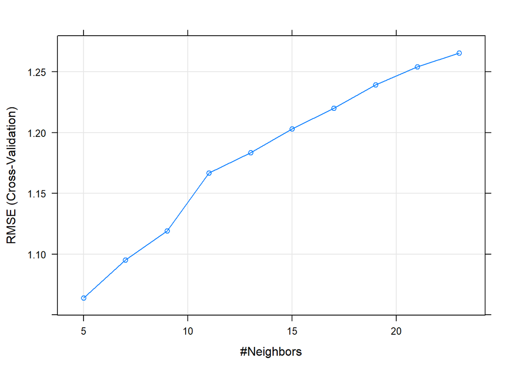

```r
plot(knnMod)
```

```r
rpartMod <- train(decrDaysThisCycle ~ ., method='rpart', tuneLength=9, data=trainingSet)
```

```r
glmMod <- train(decrDaysThisCycle ~ .,
                method='glm', data=trainingSet)
```

```r
predKNN <- predict(knnMod, testingSet)
predRPART <- predict(rpartMod, testingSet)
```

```r
predGLM <- predict(glmMod, testingSet)
```

```r
length=length(testingSet$decrDaysThisCycle)
```

```r
sumKNN <- sum(predKNN==testingSet$decrDaysThisCycle)
sumRPart <- sum(predRPART==testingSet$decrDaysThisCycle)
```

```r
sumGLM <- sum(predGLM==testingSet$decrDaysThisCycle)
```

```r
accuracy_KNN <- sumKNN/length
accuracy_RPART <- sumRPart/length
```

```r
accuracy_GLM <- sumGLM/length
```

```r
predDF2 <- data.frame(predRF,predKNN,predRPART,predGLM,
                      TYPE=testingSet$decrDaysThisCycle)
colnames(predDF2) <- c('RandomForest','KNN','Rpart','GLM','TrueValue')

results <- c(round(accuracy_rfMod,2),
             round(accuracy_KNN,2),
             round(accuracy_RPART,2),
             round(accuracy_GLM,2),
             round(100,2))

results <- as.factor(results)
results <- t(data.frame(results))
colnames(results) <- c('RandomForest','KNN','Rpart','GLM','TrueValue')
Results <- rbind(predDF2, results)
Results
```

```
##                     RandomForest  KNN            Rpart                 GLM
## 2012-03-06                  3.99  5.2                4    4.41654819611789
## 2012-03-09                 3.982  3.2                4    3.89724852476453
## 2012-03-13                     3  2.4                3    3.28791137748239
## 2012-03-14                     3    4                3    3.92381667125139
## 2012-03-20                     1    1                1    1.12106526722855
## 2012-03-23                     1  1.2                1     1.3072109671944
## 2012-04-04                     3  4.2                3    3.69993196664257
## 2012-04-10                     1  1.2                1    1.41266916574652
## 2012-04-26 -1.15818465928896e-15    0                0  -0.452819764655824
## 2012-05-04 -1.25410792861658e-15    0                0  -0.554119880886433
## 2012-05-17                 1.998  3.2                2    3.22495659139115
## 2012-05-21                 1.006    1                1    1.63595830445111
## 2012-05-30                     3  2.8                3    3.43029352951083
## 2012-06-08                     1  0.4                1     1.2030631348265
## 2012-06-12 -8.33555446888568e-16    0                0  -0.224021690889782
## 2012-06-13 -9.34363697524532e-16  0.2                0  -0.135159530048213
## 2012-06-14 -9.52571355128384e-16    0                0  0.0103222746595462
## 2012-06-19                 1.994  0.6                2    3.35783284748428
## 2012-07-02  -1.0405010186787e-15    0                0  -0.439371581453153
## 2012-07-10                 3.998  5.4                4    4.40282230073301
## 2012-07-13                     2  2.8                2    3.51617750602203
## 2012-07-19 -1.16928688953521e-15    0                0  -0.664651493186763
## 2012-07-20                 4.996  5.4                5    4.06308645730994
## 2012-07-30                     2  2.2                2    3.11910981780276
## 2012-07-31                     2  2.6                2    3.40341493741573
## 2012-08-01                 1.994  3.6                2    3.26500853831038
## 2012-08-09                     1    1                1    1.39734533852713
## 2012-08-14                     8  5.4 7.45238095238095    4.69914292426322
## 2012-08-17                     8  6.6 7.45238095238095    4.55468469253308
## 2012-08-20                     8  6.8 7.45238095238095    4.68048979687643
## 2012-08-27                 1.996  3.2                2    3.47423631712925
## 2012-08-28                     2  1.8                2    3.37990725867635
## 2012-08-29                     1  0.4                1    1.10848836991716
## 2012-08-31 -1.25943699913478e-15    0                0  -0.290123002320069
## 2012-09-06                     2  2.8                2    3.36041763560902
## 2012-09-13                     2  1.8                2    3.17715939907413
## 2012-09-14                     2  1.6                2    3.05302074938274
## 2012-09-18                 1.996  2.4                2    2.72437328063717
## 2012-09-20 -1.30384592011978e-15    0                0  -0.547929664495428
```

[output cut: 1159 more lines]

```
## 2019-12-17         0
## 2020-01-03         3
## 2020-01-10         0
## 2020-01-15         0
## 2020-01-17         2
## 2020-01-21         2
## 2020-01-22         0
## 2020-01-29         3
## 2020-02-04         0
## 2020-02-11         0
## 2020-02-19         3
## 2020-02-24         2
## 2020-03-03         1
## 2020-03-04         3
## results          100
```

```r
predRF_round <- predict(rfMod, testingSet)

predRF_round <- ifelse(predRF_round<0,0,round(predRF,0))

predDF_round <- data.frame(predRF_round, IncreasingDaysThisCycle=testingSet$decrDaysThisCycle)
predDF_round
```

```
##            predRF_round IncreasingDaysThisCycle
## 2012-03-06            4                       4
## 2012-03-09            4                       4
## 2012-03-13            3                       3
## 2012-03-14            3                       3
## 2012-03-20            1                       1
## 2012-03-23            1                       1
## 2012-04-04            3                       3
## 2012-04-10            1                       1
## 2012-04-26            0                       0
## 2012-05-04            0                       0
## 2012-05-17            2                       2
## 2012-05-21            1                       1
## 2012-05-30            3                       3
## 2012-06-08            1                       1
## 2012-06-12            0                       0
## 2012-06-13            0                       0
## 2012-06-14            0                       0
## 2012-06-19            2                       2
## 2012-07-02            0                       0
## 2012-07-10            4                       4
## 2012-07-13            2                       2
## 2012-07-19            0                       0
## 2012-07-20            5                       5
## 2012-07-30            2                       2
## 2012-07-31            2                       2
## 2012-08-01            2                       2
## 2012-08-09            1                       1
## 2012-08-14            8                       8
## 2012-08-17            8                       8
## 2012-08-20            8                       8
## 2012-08-27            2                       2
## 2012-08-28            2                       2
## 2012-08-29            1                       1
## 2012-08-31            0                       0
## 2012-09-06            2                       2
## 2012-09-13            2                       2
## 2012-09-14            2                       2
## 2012-09-18            2                       2
## 2012-09-20            0                       0
```

[output cut: 551 more lines]

```
## 2019-12-16            0                       0
## 2019-12-17            0                       0
## 2020-01-03            3                       3
## 2020-01-10            0                       0
## 2020-01-15            0                       0
## 2020-01-17            2                       2
## 2020-01-21            2                       2
## 2020-01-22            0                       0
## 2020-01-29            3                       3
## 2020-02-04            0                       0
## 2020-02-11            0                       0
## 2020-02-19            3                       3
## 2020-02-24            2                       2
## 2020-03-03            1                       1
## 2020-03-04            3                       3
```

```r
sum <- sum(predRF_round==testingSet$decrDaysThisCycle)
length <- length(testingSet$decrDaysThisCycle)
accuracy_rfMod_round <- (sum/length)
accuracy_rfMod_round
```

```
## [1] 0.9917355
```

```r
results_round <- c(round(accuracy_rfMod_round,2), round(100,2))
results_round <- as.factor(results_round)
results_round <- t(data.frame(results_round))

colnames(results_round) <- colnames(predDF_round)
Results_round <- rbind(predDF_round, results_round)
Results_round
```

```
##               predRF_round IncreasingDaysThisCycle
## 2012-03-06               4                       4
## 2012-03-09               4                       4
## 2012-03-13               3                       3
## 2012-03-14               3                       3
## 2012-03-20               1                       1
## 2012-03-23               1                       1
## 2012-04-04               3                       3
## 2012-04-10               1                       1
## 2012-04-26               0                       0
## 2012-05-04               0                       0
## 2012-05-17               2                       2
## 2012-05-21               1                       1
## 2012-05-30               3                       3
## 2012-06-08               1                       1
## 2012-06-12               0                       0
## 2012-06-13               0                       0
## 2012-06-14               0                       0
## 2012-06-19               2                       2
## 2012-07-02               0                       0
## 2012-07-10               4                       4
## 2012-07-13               2                       2
## 2012-07-19               0                       0
## 2012-07-20               5                       5
## 2012-07-30               2                       2
## 2012-07-31               2                       2
## 2012-08-01               2                       2
## 2012-08-09               1                       1
## 2012-08-14               8                       8
## 2012-08-17               8                       8
## 2012-08-20               8                       8
## 2012-08-27               2                       2
## 2012-08-28               2                       2
## 2012-08-29               1                       1
## 2012-08-31               0                       0
## 2012-09-06               2                       2
## 2012-09-13               2                       2
## 2012-09-14               2                       2
## 2012-09-18               2                       2
## 2012-09-20               0                       0
```

[output cut: 552 more lines]

```
## 2019-12-17               0                       0
## 2020-01-03               3                       3
## 2020-01-10               0                       0
## 2020-01-15               0                       0
## 2020-01-17               2                       2
## 2020-01-21               2                       2
## 2020-01-22               0                       0
## 2020-01-29               3                       3
## 2020-02-04               0                       0
## 2020-02-11               0                       0
## 2020-02-19               3                       3
## 2020-02-24               2                       2
## 2020-03-03               1                       1
## 2020-03-04               3                       3
## results_round         0.99                     100
```

```r
knnMod_round <- train(decrDaysThisCycle ~ .,
                method='knn', preProcess=c('center','scale'),
                tuneLength=10, trControl=trainControl(method='cv'), data=trainingSet)
```

```r
rpartMod_round <- train(decrDaysThisCycle ~ ., method='rpart', tuneLength=9, data=trainingSet)
```

```r
glmMod_round <- train(decrDaysThisCycle ~ .,
                method='glm', data=trainingSet)
```

```r
predKNN <- predict(knnMod_round, testingSet)
predKNN_round <- ifelse(predKNN<0,0,round(predKNN,0))

predRPART <- predict(rpartMod_round, testingSet)
predRPART_round <- ifelse(predRPART<0,0,round(predRPART,0))
```

```r
predGLM <- predict(glmMod_round, testingSet)
predGLM_round <- ifelse(predGLM<0,0,round(predGLM,0))
```

```r
length=length(testingSet$decrDaysThisCycle)
```

```r
sumKNN_round <- sum(predKNN_round==testingSet$decrDaysThisCycle)
sumRPart_round <- sum(predRPART_round==testingSet$decrDaysThisCycle)
```

```r
sumGLM_round <- sum(predGLM_round==testingSet$decrDaysThisCycle)
```

```r
accuracy_KNN_round <- sumKNN_round/length
accuracy_RPART_round <- sumRPart_round/length
```

```r
accuracy_GLM_round <- sumGLM_round/length
```

```r
predDF2_round <- data.frame(predRF_round,predKNN_round,predRPART_round,predGLM_round,
                      DecreasingDaysThisCycle=testingSet$decrDaysThisCycle)
colnames(predDF2_round) <- c('RandomForest_round','KNN_round','Rpart_round','GLM_round','DecreasingDaysThisCycle')

results_round <- c(round(accuracy_rfMod_round,2),
             round(accuracy_KNN_round,2),
             round(accuracy_RPART_round,2),
             round(accuracy_GLM_round,2),
             round(100,2))

results_round <- as.factor(results_round)
results_round <- t(data.frame(results_round))
colnames(results_round) <- c('RandomForest_round','KNN_round','Rpart_round','GLM_round','DecreasingDaysThisCycle')
Results_round <- rbind(predDF2_round, results_round)
Results_round
```

```
##               RandomForest_round KNN_round Rpart_round GLM_round
## 2012-03-06                     4         5           4         4
## 2012-03-09                     4         3           4         4
## 2012-03-13                     3         2           3         3
## 2012-03-14                     3         4           3         4
## 2012-03-20                     1         1           1         1
## 2012-03-23                     1         1           1         1
## 2012-04-04                     3         4           3         4
## 2012-04-10                     1         1           1         1
## 2012-04-26                     0         0           0         0
## 2012-05-04                     0         0           0         0
## 2012-05-17                     2         3           2         3
## 2012-05-21                     1         1           1         2
## 2012-05-30                     3         3           3         3
## 2012-06-08                     1         0           1         1
## 2012-06-12                     0         0           0         0
## 2012-06-13                     0         0           0         0
## 2012-06-14                     0         0           0         0
## 2012-06-19                     2         1           2         3
## 2012-07-02                     0         0           0         0
## 2012-07-10                     4         5           4         4
## 2012-07-13                     2         3           2         4
## 2012-07-19                     0         0           0         0
## 2012-07-20                     5         5           5         4
## 2012-07-30                     2         2           2         3
## 2012-07-31                     2         3           2         3
## 2012-08-01                     2         4           2         3
## 2012-08-09                     1         1           1         1
## 2012-08-14                     8         5           7         5
## 2012-08-17                     8         7           7         5
## 2012-08-20                     8         7           7         5
## 2012-08-27                     2         3           2         3
## 2012-08-28                     2         2           2         3
## 2012-08-29                     1         0           1         1
## 2012-08-31                     0         0           0         0
## 2012-09-06                     2         3           2         3
## 2012-09-13                     2         2           2         3
## 2012-09-14                     2         2           2         3
## 2012-09-18                     2         2           2         3
## 2012-09-20                     0         0           0         0
```

[output cut: 1159 more lines]

```
## 2019-12-17                          0
## 2020-01-03                          3
## 2020-01-10                          0
## 2020-01-15                          0
## 2020-01-17                          2
## 2020-01-21                          2
## 2020-01-22                          0
## 2020-01-29                          3
## 2020-02-04                          0
## 2020-02-11                          0
## 2020-02-19                          3
## 2020-02-24                          2
## 2020-03-03                          1
## 2020-03-04                          3
## results_round                     100
```

Lets compare this to the table we just saw earlier when the values weren’t rounded or zero if less than zero.

```r
Results
```

```
##                     RandomForest  KNN            Rpart                 GLM
## 2012-03-06                  3.99  5.2                4    4.41654819611789
## 2012-03-09                 3.982  3.2                4    3.89724852476453
## 2012-03-13                     3  2.4                3    3.28791137748239
## 2012-03-14                     3    4                3    3.92381667125139
## 2012-03-20                     1    1                1    1.12106526722855
## 2012-03-23                     1  1.2                1     1.3072109671944
## 2012-04-04                     3  4.2                3    3.69993196664257
## 2012-04-10                     1  1.2                1    1.41266916574652
## 2012-04-26 -1.15818465928896e-15    0                0  -0.452819764655824
## 2012-05-04 -1.25410792861658e-15    0                0  -0.554119880886433
## 2012-05-17                 1.998  3.2                2    3.22495659139115
## 2012-05-21                 1.006    1                1    1.63595830445111
## 2012-05-30                     3  2.8                3    3.43029352951083
## 2012-06-08                     1  0.4                1     1.2030631348265
## 2012-06-12 -8.33555446888568e-16    0                0  -0.224021690889782
## 2012-06-13 -9.34363697524532e-16  0.2                0  -0.135159530048213
## 2012-06-14 -9.52571355128384e-16    0                0  0.0103222746595462
## 2012-06-19                 1.994  0.6                2    3.35783284748428
## 2012-07-02  -1.0405010186787e-15    0                0  -0.439371581453153
## 2012-07-10                 3.998  5.4                4    4.40282230073301
## 2012-07-13                     2  2.8                2    3.51617750602203
## 2012-07-19 -1.16928688953521e-15    0                0  -0.664651493186763
## 2012-07-20                 4.996  5.4                5    4.06308645730994
## 2012-07-30                     2  2.2                2    3.11910981780276
## 2012-07-31                     2  2.6                2    3.40341493741573
## 2012-08-01                 1.994  3.6                2    3.26500853831038
## 2012-08-09                     1    1                1    1.39734533852713
## 2012-08-14                     8  5.4 7.45238095238095    4.69914292426322
## 2012-08-17                     8  6.6 7.45238095238095    4.55468469253308
## 2012-08-20                     8  6.8 7.45238095238095    4.68048979687643
## 2012-08-27                 1.996  3.2                2    3.47423631712925
## 2012-08-28                     2  1.8                2    3.37990725867635
## 2012-08-29                     1  0.4                1    1.10848836991716
## 2012-08-31 -1.25943699913478e-15    0                0  -0.290123002320069
## 2012-09-06                     2  2.8                2    3.36041763560902
## 2012-09-13                     2  1.8                2    3.17715939907413
## 2012-09-14                     2  1.6                2    3.05302074938274
## 2012-09-18                 1.996  2.4                2    2.72437328063717
## 2012-09-20 -1.30384592011978e-15    0                0  -0.547929664495428
```

[output cut: 1159 more lines]

```
## 2019-12-17         0
## 2020-01-03         3
## 2020-01-10         0
## 2020-01-15         0
## 2020-01-17         2
## 2020-01-21         2
## 2020-01-22         0
## 2020-01-29         3
## 2020-02-04         0
## 2020-02-11         0
## 2020-02-19         3
## 2020-02-24         2
## 2020-03-03         1
## 2020-03-04         3
## results          100
```

```r
sYELP1$Date <- row.names(sYELP1)
testingSet$Date <- row.names(testingSet)
Results_round$Date <- row.names(Results_round)

sYELP1 <- merge(testingSet,Results_round, by.x='Date', by.y='Date')
tbl <- rbind(head(sYELP1),tail(sYELP1))
tbl
```

```
##           Date DayOfWeek stockDayValue  lag1 today2lag1 decrDaysThisCycle
## 1   2012-03-06   Tuesday         20.50 20.99  0.9766556                 4
## 2   2012-03-09    Friday         19.80 20.00  0.9899999                 4
## 3   2012-03-13   Tuesday         23.30 22.49  1.0360160                 3
## 4   2012-03-14 Wednesday         22.32 23.30  0.9579400                 3
## 5   2012-03-20   Tuesday         22.90 22.99  0.9960853                 1
## 6   2012-03-23    Friday         23.18 23.22  0.9982774                 1
## 600 2020-02-04   Tuesday         34.02 32.94  1.0327869                 0
## 601 2020-02-11   Tuesday         34.76 34.20  1.0163742                 0
## 602 2020-02-19 Wednesday         34.04 34.57  0.9846688                 3
## 603 2020-02-24    Monday         32.42 34.00  0.9535294                 2
## 604 2020-03-03   Tuesday         30.59 31.65  0.9665087                 1
## 605 2020-03-04 Wednesday         31.39 30.59  1.0261523                 3
##     nTimesDecrDayCountsOccurs todayLessThanlag1 incrDaysThisCycle
## 1                          25                 1                 0
```

[output cut: 37 more lines]

```r
Results_round$RandomForest_round <-
  as.numeric(paste(Results_round$RandomForest_round))
Results_round$KNN_round <-
  as.numeric(paste(Results_round$KNN_round))
Results_round$Rpart_round <-
  as.numeric(paste(Results_round$Rpart_round))
Results_round$GLM_round <-
  as.numeric(paste(Results_round$GLM_round))
Results_round$DecreasingDaysThisCycle <-
  as.numeric(paste(Results_round$DecreasingDaysThisCycle))



Results_round$mostVoted <- ifelse(
                        (Results_round$RandomForest_round==Results_round$KNN_round |                        Results_round$RandomForest_round==Results_round$Rpart_round |                        Results_round$RandomForest_round==Results_round$GLM_round),

ifelse(Results_round$KNN_round==Results_round$Rpart_round |                           Results_round$KNN_round==Results_round$GLM_round,
        Results_round$RandomForest_round,
        ifelse(Results_round$Rpart_round ==Results_round$GLM_round,
               Results_round$Rpart_round,
               Results_round$RandomForest_round)),
                               ifelse(Results_round$KNN_round==Results_round$Rpart_round |                          Results_round$KNN_round==Results_round$GLM_round,
        Results_round$KNN_round,
        ifelse(Results_round$Rpart_round==Results_round$GLM_round,
               Results_round$Rpart_round,
               ifelse(Results_round$Rpart_round>Results_round$RandomForest_round,
                      Results_round$Rpart_round,
                      Results_round$RandomForest_round))
      )
)

sMost <- sum(Results_round$mostVoted==Results_round$DecreasingDaysThisCycle)
lMost <- length(Results_round$DecreasingDaysThisCycle)-1
accMost <- sMost/lMost
accMost
```

```
## [1] 0.9867769
```

```r
Results_round
```

```
##               RandomForest_round KNN_round Rpart_round GLM_round
## 2012-03-06                  4.00      5.00        4.00      4.00
## 2012-03-09                  4.00      3.00        4.00      4.00
## 2012-03-13                  3.00      2.00        3.00      3.00
## 2012-03-14                  3.00      4.00        3.00      4.00
## 2012-03-20                  1.00      1.00        1.00      1.00
## 2012-03-23                  1.00      1.00        1.00      1.00
## 2012-04-04                  3.00      4.00        3.00      4.00
## 2012-04-10                  1.00      1.00        1.00      1.00
## 2012-04-26                  0.00      0.00        0.00      0.00
## 2012-05-04                  0.00      0.00        0.00      0.00
## 2012-05-17                  2.00      3.00        2.00      3.00
## 2012-05-21                  1.00      1.00        1.00      2.00
## 2012-05-30                  3.00      3.00        3.00      3.00
## 2012-06-08                  1.00      0.00        1.00      1.00
## 2012-06-12                  0.00      0.00        0.00      0.00
## 2012-06-13                  0.00      0.00        0.00      0.00
## 2012-06-14                  0.00      0.00        0.00      0.00
## 2012-06-19                  2.00      1.00        2.00      3.00
## 2012-07-02                  0.00      0.00        0.00      0.00
## 2012-07-10                  4.00      5.00        4.00      4.00
## 2012-07-13                  2.00      3.00        2.00      4.00
## 2012-07-19                  0.00      0.00        0.00      0.00
## 2012-07-20                  5.00      5.00        5.00      4.00
## 2012-07-30                  2.00      2.00        2.00      3.00
## 2012-07-31                  2.00      3.00        2.00      3.00
## 2012-08-01                  2.00      4.00        2.00      3.00
## 2012-08-09                  1.00      1.00        1.00      1.00
## 2012-08-14                  8.00      5.00        7.00      5.00
## 2012-08-17                  8.00      7.00        7.00      5.00
## 2012-08-20                  8.00      7.00        7.00      5.00
## 2012-08-27                  2.00      3.00        2.00      3.00
## 2012-08-28                  2.00      2.00        2.00      3.00
## 2012-08-29                  1.00      0.00        1.00      1.00
## 2012-08-31                  0.00      0.00        0.00      0.00
## 2012-09-06                  2.00      3.00        2.00      3.00
## 2012-09-13                  2.00      2.00        2.00      3.00
## 2012-09-14                  2.00      2.00        2.00      3.00
## 2012-09-18                  2.00      2.00        2.00      3.00
## 2012-09-20                  0.00      0.00        0.00      0.00
```

[output cut: 1159 more lines]

```
## 2019-12-17                          0    2019-12-17      0.00
## 2020-01-03                          3    2020-01-03      3.00
## 2020-01-10                          0    2020-01-10      0.00
## 2020-01-15                          0    2020-01-15      0.00
## 2020-01-17                          2    2020-01-17      2.00
## 2020-01-21                          2    2020-01-21      2.00
## 2020-01-22                          0    2020-01-22      0.00
## 2020-01-29                          3    2020-01-29      3.00
## 2020-02-04                          0    2020-02-04      0.00
## 2020-02-11                          0    2020-02-11      0.00
## 2020-02-19                          3    2020-02-19      3.00
## 2020-02-24                          2    2020-02-24      2.00
## 2020-03-03                          1    2020-03-03      1.00
## 2020-03-04                          3    2020-03-04      3.00
## results_round                     100 results_round      0.99
```

The accuracy in prediction is about the same for decreasing days in the cycle as the target instead of the increasing days in the cycle that was the target when predicting the AAL stock increasing days by select features.

Now, lets see how well these algorithms predict the NextDayPrice. But first remove the added predictive measures just done.

```r
sYELP1 <- sYELP[,c(4,5,9,14,15,19,20,21,24,25)]
sYELP1$NextDayPrice <- lead(sYELP1$stockDayValue,1)
sYELP1 <- sYELP1[complete.cases(sYELP1$NextDayPrice),]
row.names(sYELP1) <- as.factor(sYELP1$Date)
sYELP1 <- sYELP1[,-c(1)]
```

Now, we can see how well the next day price is predicted.

```r
set.seed(12356789)

inTrain <- createDataPartition(y=sYELP1$NextDayPrice, p=0.7, list=FALSE)

trainingSet <- sYELP1[inTrain,]
testingSet <- sYELP1[-inTrain,]
```

```r
rfMod <- train(NextDayPrice ~ ., method='rf', data=(trainingSet),
               trControl=trainControl(method='cv'), number=5)
```

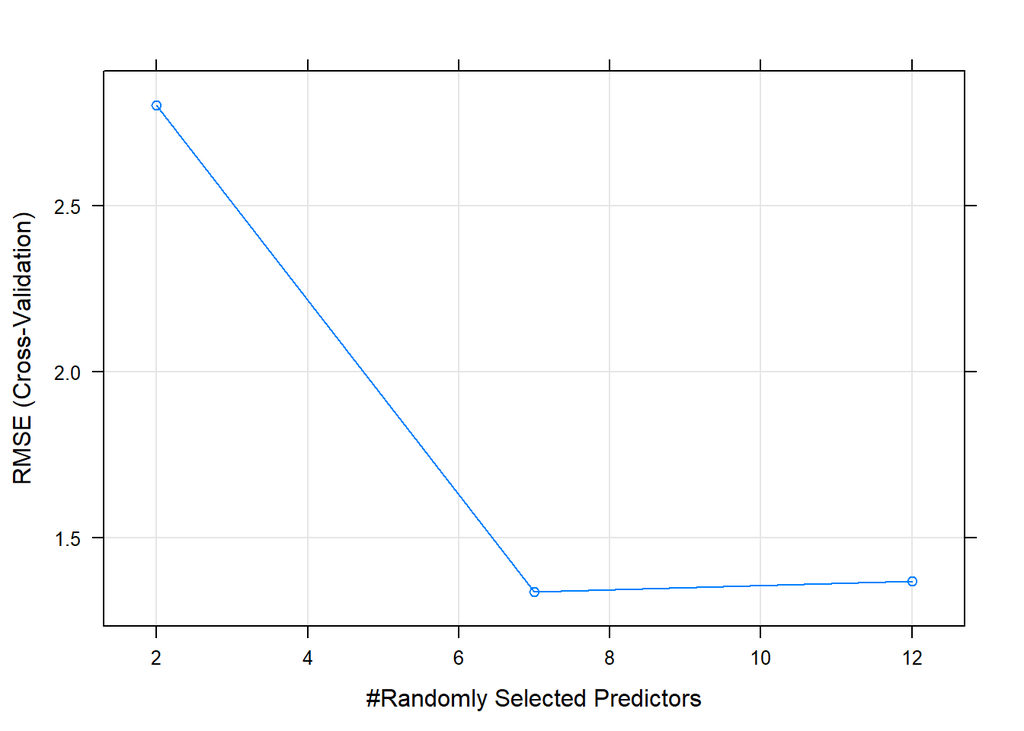

```r
plot(rfMod)
```

```r
predRF <- predict(rfMod, testingSet)

predDF <- data.frame(predRF, nextDayPrice=testingSet$NextDayPrice)
predDF
```

```
##              predRF nextDayPrice
## 2012-03-16 21.85275        22.99
## 2012-03-21 23.44335        23.22
## 2012-03-23 23.51716        24.60
## 2012-03-27 26.73156        28.09
## 2012-03-29 27.36484        26.89
## 2012-04-02 26.96272        26.70
## 2012-04-12 26.50815        26.33
## 2012-04-13 25.49692        25.87
## 2012-04-19 23.62690        23.10
## 2012-04-24 20.59442        21.13
## 2012-04-25 21.28897        21.20
## 2012-04-26 21.39161        21.90
## 2012-05-04 21.33528        21.41
## 2012-05-11 20.17666        20.04
## 2012-05-22 19.61389        18.32
## 2012-05-29 16.65153        16.61
## 2012-06-20 20.08548        21.00
## 2012-06-25 22.91552        22.04
## 2012-06-26 22.76131        22.79
## 2012-07-03 25.43444        26.16
## 2012-07-09 24.60876        22.63
## 2012-07-11 21.52866        22.14
## 2012-07-12 21.78514        21.64
## 2012-07-18 23.16843        24.00
## 2012-07-23 22.58773        22.51
## 2012-08-03 23.82152        25.43
## 2012-08-07 26.21300        26.46
## 2012-08-08 26.10273        25.73
## 2012-08-22 18.21623        18.19
## 2012-09-12 25.03431        23.95
## 2012-09-25 25.70208        25.68
## 2012-09-28 27.00187        27.76
## 2012-10-03 28.31028        28.89
## 2012-10-05 27.35450        28.27
## 2012-10-08 27.31120        27.43
## 2012-10-09 27.32595        25.61
## 2012-10-10 26.70605        25.73
## 2012-10-11 25.42030        25.24
## 2012-10-18 24.80692        24.61
```

[output cut: 550 more lines]

```
## 2019-12-23 34.35185        34.06
## 2019-12-26 34.79605        34.85
## 2019-12-31 34.11788        34.77
## 2020-01-10 35.53191        36.23
## 2020-01-29 34.67837        34.77
## 2020-02-04 34.15307        34.66
## 2020-02-07 34.32450        34.20
## 2020-02-11 34.97176        35.36
## 2020-02-13 35.99384        35.23
## 2020-02-19 34.04413        34.64
## 2020-02-20 34.00272        34.00
## 2020-02-27 31.43517        31.27
## 2020-03-02 31.46620        30.59
## 2020-03-04 30.77505        29.14
## 2020-03-09 27.38778        27.81
```

```r
sum <- sum(predRF==testingSet$NextDayPrice)
length <- length(testingSet$NextDayPrice)
accuracy_rfMod <- (sum/length)
accuracy_rfMod
```

```
## [1] 0
```

```r
results <- c(round(accuracy_rfMod,2), round(100,2))
results <- as.factor(results)
results <- t(data.frame(results))

colnames(results) <- colnames(predDF)
Results <- rbind(predDF, results)
Results
```

```
##                      predRF nextDayPrice
## 2012-03-16    21.8527515231        22.99
## 2012-03-21 23.4433496296334    23.219999
## 2012-03-23 23.5171571670001         24.6
## 2012-03-27 26.7315608579667        28.09
## 2012-03-29 27.3648435893667    26.889999
## 2012-04-02 26.9627240613667    26.700001
## 2012-04-12 26.5081473320333        26.33
## 2012-04-13    25.4969236192    25.870001
## 2012-04-19 23.6269034890667         23.1
## 2012-04-24 20.5944217580667    21.129999
## 2012-04-25 21.2889651799667    21.200001
## 2012-04-26 21.3916120998333         21.9
## 2012-05-04 21.3352766541238        21.41
## 2012-05-11 20.1766577361667    20.040001
## 2012-05-22 19.6138927228333        18.32
## 2012-05-29 16.6515347609333    16.610001
## 2012-06-20 20.0854815850334           21
## 2012-06-25 22.9155171123334    22.040001
## 2012-06-26 22.7613093761001    22.790001
## 2012-07-03 25.4344445799667        26.16
## 2012-07-09 24.6087567422334    22.629999
## 2012-07-11 21.5286605817334    22.139999
## 2012-07-12 21.7851445682333    21.639999
## 2012-07-18 23.1684302918667           24
## 2012-07-23 22.5877293654667        22.51
## 2012-08-03    23.8215202886        25.43
## 2012-08-07 26.2130035106667    26.459999
## 2012-08-08 26.1027298571667        25.73
## 2012-08-22    18.2162299556    18.190001
## 2012-09-12    25.0343093901    23.950001
## 2012-09-25    25.7020756728        25.68
## 2012-09-28     27.001871156        27.76
## 2012-10-03 28.3102780652333    28.889999
## 2012-10-05    27.3545024159        28.27
## 2012-10-08 27.3111955584667        27.43
## 2012-10-09 27.3259489885667    25.610001
## 2012-10-10 26.7060549194333        25.73
## 2012-10-11     25.420298464        25.24
## 2012-10-18 24.8069210840334    24.610001
```

[output cut: 551 more lines]

```
## 2019-12-26 34.7960519294667    34.849998
## 2019-12-31 34.1178770807667        34.77
## 2020-01-10 35.5319101971333        36.23
## 2020-01-29 34.6783671981667        34.77
## 2020-02-04 34.1530748402667        34.66
## 2020-02-07 34.3244970365666    34.200001
## 2020-02-11    34.9717566107    35.360001
## 2020-02-13 35.9938440144666        35.23
## 2020-02-19 34.0441333275667    34.639999
## 2020-02-20 34.0027201361333           34
## 2020-02-27    31.4351719537        31.27
## 2020-03-02 31.4662001675333        30.59
## 2020-03-04 30.7750547568333    29.139999
## 2020-03-09    27.3877826918    27.809999
## results                   0          100
```

```r
knnMod <- train(NextDayPrice ~ .,
                method='knn', preProcess=c('center','scale'),
                tuneLength=10, trControl=trainControl(method='cv'), data=trainingSet)
```

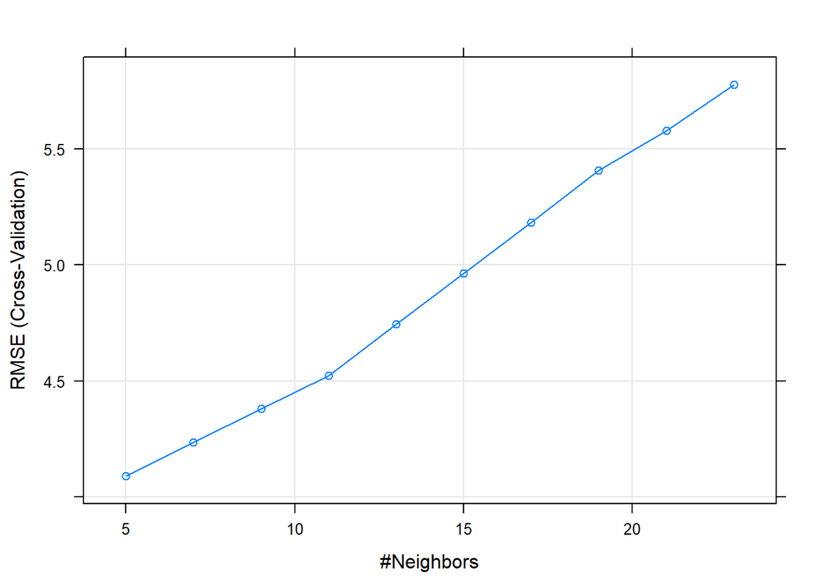

```r
plot(knnMod)
```

```r
rpartMod <- train(NextDayPrice ~ ., method='rpart', tuneLength=9, data=trainingSet)
```

```r
glmMod <- train(NextDayPrice ~ .,
                method='glm', data=trainingSet)
```